# Project CO2 - Bayesian Statistics

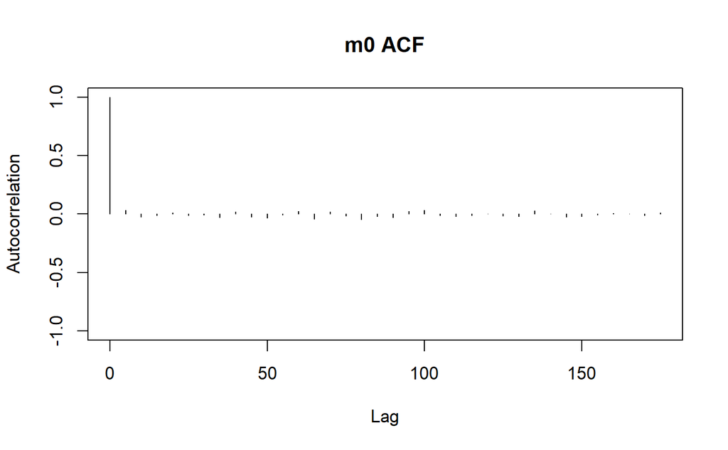

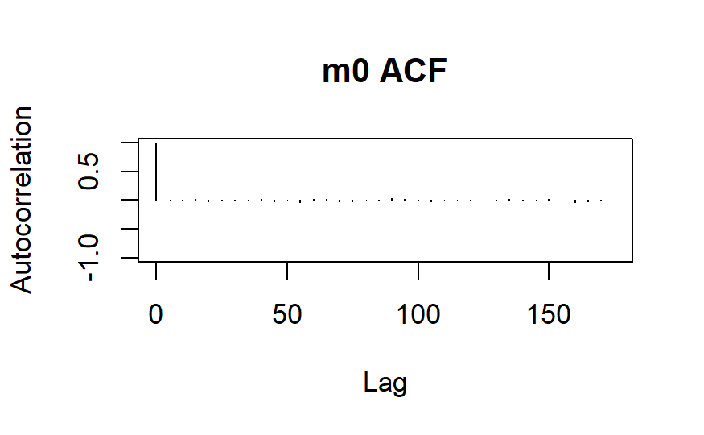

```r
autocorr.plot(outputmcmcAR$samples[,c('m0')], main= "m0 ACF")
```

```r
# Out of sample prediction
yp_pred = outputmcmcAR$mean$ypOut         # Here 'yp_pred' is the 'delta-log'
q1_pred = outputmcmcAR$q2.5$ypOut         # Credible interval
q2_pred = outputmcmcAR$q97.5$ypOut

# Years for prediction
new_years <- seq(2021, 2021 + Npred - 1)


# Plots
plot(year_78[1:length(delta_logdata_78)], delta_logdata_78, type='l', xlim = c(min(year_78), 2030), ylab="Delta log-co2", main="Delta log-co2 prediction", xlab="Year")
lines(new_years, yp_pred, pch="*", col="darkorange")
```

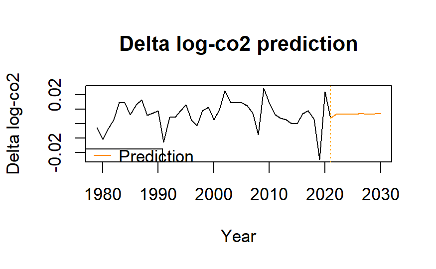

```r
abline(v=min(new_years), col="orange", lty = 3)
# lines(new_years, q1_pred, type="l", col="orange", lwd = 1.5)
# lines(new_years, q2_pred, type="l", col="orange", lwd = 1.5)

legend("bottomleft", legend=c("Prediction"), col=c("darkorange"), lty=1)
```

We need now to convert the prediction from the Delta log CO2 to total Annual CO2.

```r
# Reversing the delta-log relation
delta_log_predicted = yp_pred[2:(Npred)]    # discard the first one (last data point)
last_log_point = world_data$CO2_log[121]

log_yp_pred <- array(0, dim = c(length(delta_log_predicted)))
log_yp_pred[1] = last_log_point + delta_log_predicted[1]

# calculating log_yp_pred
for (i in seq(length(delta_log_predicted) - 1)){
  log_yp_pred[i+1] = log_yp_pred[i] + delta_log_predicted[i+1]
}

# Final values in Billions of tons
yp = 10^log_yp_pred


# Years for AnnualCo2
new_years_p = new_years[2:length(new_years)] + 1   # remove the first and shift by 1



# Calculating the critical year
CO2_bucket = 250
i = 0
while (CO2_bucket > 0){
  i = i+1
  critical_year = new_years_p[i]
  CO2_bucket = CO2_bucket - yp[i]


}



# Plots
plot(world_data$Year, world_data$AnnualCO2, type='l', col='darkgreen', ylab="Annual CO2 (billion t)", main="CO2 Emissions for the World", xlab="Year", xlim = c(min(world_data$Year), 2030), ylim = c(min(world_data$AnnualCO2), 42))
points(world_data$Year, world_data$AnnualCO2, col='darkgreen', pch=16, cex=0.5)
```

```r
# Prediction
lines(new_years_p, yp, pch="*", col="darkorange")
points(new_years_p, yp, pch=16, cex=0.5, col="darkorange")
```

```r
points(critical_year, yp[i], pch=1, cex=1, lwd=2, col="red")

# Critical year line
abline(v=critical_year, col="red", lty = 3)
```

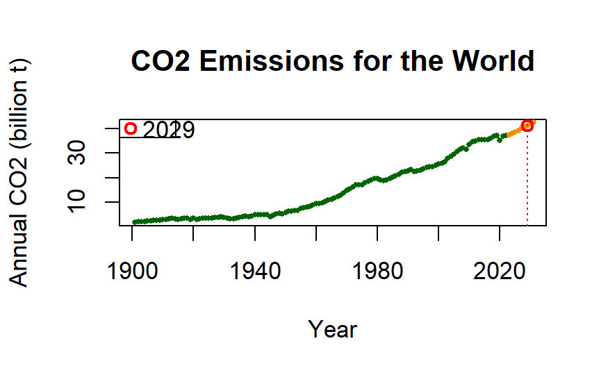

```r
# Add a legend
legend("topleft", legend=critical_year, pch=1, col="red", pt.cex=1, pt.lwd=2)
```

Based on our analysis, continuing the current emissions trajectory could push us towards **1.5°C** warming by **2029.**

## White Noise Model with switching variance

In our previous analyses, we have examined the trends in the increase of CO2 emissions.

Now we want to ask a different question: **can we detect global crisis and major worldwide events by looking at CO2 emissions alone?**

**Do they cause a noticeable variance in the trend of CO2 emissions?**

We will carry on this analysis by fitting a white noise model with switching variance on the increment of the log of CO2 emissions.

We will split our data by leveraging the change points discovered in two sub-datasets: years **before** **1949** (5% quantile of the change point on the variance) and **after** **1978** (95% quantile of the change point on the mean).

### After 1978

We start our analysis with the years after 1978.

The model is as follows:
$$x_t :=\log(y_{t+1})-\log(y_t)$$
and we assume that
$$x_t \stackrel{iid}{\sim} \mathcal{N}(\mu,\sigma_t^2)$$
with
$$\sigma_t^{-2}=\beta_1+\beta_2 \delta_t \qquad \delta_t \sim Ber(p)$$

We assume the following priors:
$$\begin{split}
& \beta_1 \sim \mathcal{G}(0.001, 0.001) \\
& \beta_2 \sim \mathcal{G}(0.001, 0.001) \\
& \delta_t \sim Ber(p) \\
& p \sim Beta(1,1) \\
& \mu\sim \mathcal{N}(0,10) \\
\end{split}$$

We choose the priors for $\mu$, $\beta_1$, $\beta_2$ and $p$ to be weakly informative.

```r
# Filtering for data before 1949 and after 1978
world_data_after1978 <- world_data[world_data$Year > 1978,]
world_data_before1949 <- world_data[world_data$Year < 1949,]



# After 1978
CO2_log_78 = log(world_data_after1978$AnnualCO2, 10)
n1 = length(CO2_log_78)

delta_logdata_78 = CO2_log_78[2:n1] - CO2_log_78[1:n1-1]

# Years
year_78 = world_data_after1978$Year



# Before 1949
CO2_log_49 = log(world_data_before1949$AnnualCO2, 10)
n1 = length(CO2_log_49)

delta_logdata_49 = CO2_log_49[2:n1]-CO2_log_49[1:n1-1]

# Years
year_49 = world_data_before1949$Year
```

To make the variability of the data more enhanced we apply two transformations:

- Firstly we normalize the data
- Then we elevate to the power 3

This makes outliers in the data easier to spot.

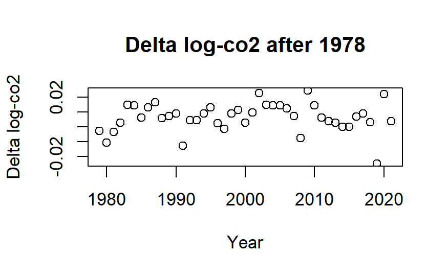

```r
# Enchancing the data
# Normalization step
mean_val <- mean(delta_logdata_78)
sd_val <- sd(delta_logdata_78)

delta_logdata_78_norm <- (delta_logdata_78 - mean_val) / sd_val

# To enhance the varability in the data we evevate it power 3
delta_logdata_78_p3 = delta_logdata_78_norm^3


# Plots
# Normal
plot(year_78[1:length(delta_logdata_78)], delta_logdata_78, ylab="Delta log-co2", main="Delta log-co2 after 1978", xlab="Year")
```

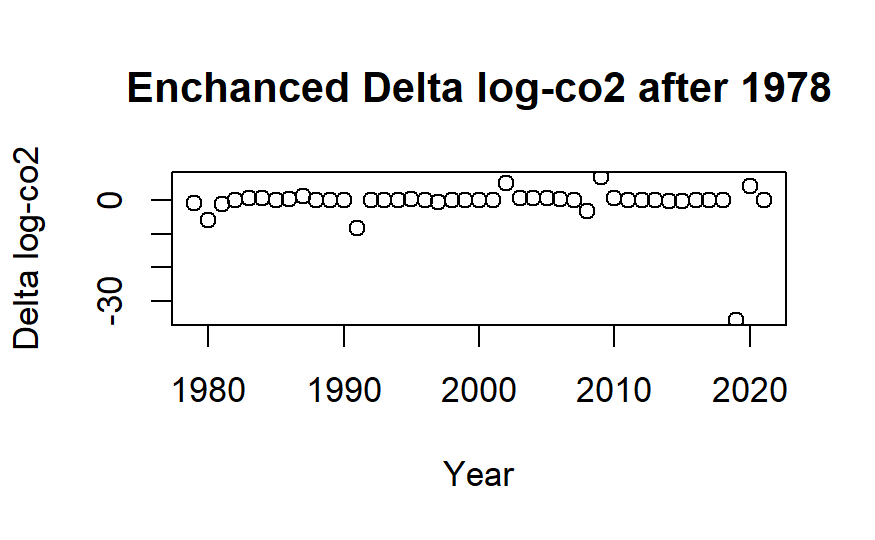

```r
# Enhanced
plot(year_78[1:length(delta_logdata_78_p3)], delta_logdata_78_p3, ylab="Delta log-co2", main="Enchanced Delta log-co2 after 1978", xlab="Year")
```

```r
model4.string <-"model {
  #likeliohood
  for(i in 1:N){
    x[i] ~ dnorm(mu, inv.var[i])
    inv.var[i] <- beta[1] + beta[2] * d[i]
  }

  # Prior for d[i]
  for(k in 1:N){
    d[k] ~ dbern(p)             # probabilities
  }

  # Prior for beta
    # beta[1] ~ dexp(0.1)
    # beta[2] ~ dexp(0.1)
    beta[1] ~ dgamma(0.001, 0.001)    # Non informative
    beta[2] ~ dgamma(0.001, 0.001)

  # Prior for beta
   p ~ dbeta(1,1)

  # Prior for the mean
  mu   ~ dnorm(0, 0.1)
}"

# After 1978
data_78 <- list("x" = delta_logdata_78_p3, "N" = length(delta_logdata_78_p3))
samp_78 <- jags(model.file = textConnection(model4.string),
                     data=data_78,
                     parameters.to.save= c("inv.var", "d", "mu"),
                     n.adapt=1000, n.iter=50000, n.chains = 1, n.burnin = 2000,
                     n.thin = 5)
```

[output not shown]

[output cut: 117 more lines]

[output not shown]

```r
# Output
samp_78
```

```
JAGS output for model '7', generated by jagsUI.
Estimates based on 1 chains of 50000 iterations,
adaptation = 1000 iterations (sufficient),
burn-in = 2000 iterations and thin rate = 5,
yielding 9600 total samples from the joint posterior.
MCMC ran for 0.033 minutes at time 2024-06-04 18:55:45.815875.
```

|  | mean | sd | 2.5% | 50% | 97.5% | overlap0 | f |
| --- | --- | --- | --- | --- | --- | --- | --- |
| inv.var[1] | 4.540 | 3.236 | 0.003 | 5.045 | 10.504 | FALSE | 1.000 |
| inv.var[2] | 0.006 | 0.003 | 0.002 | 0.006 | 0.013 | FALSE | 1.000 |
| inv.var[3] | 2.329 | 2.818 | 0.002 | 0.010 | 7.901 | FALSE | 1.000 |
| inv.var[4] | 7.012 | 2.848 | 3.113 | 6.455 | 13.886 | FALSE | 1.000 |
| inv.var[5] | 6.775 | 2.952 | 0.009 | 6.337 | 13.589 | FALSE | 1.000 |
| inv.var[6] | 6.876 | 2.915 | 2.494 | 6.385 | 13.751 | FALSE | 1.000 |
| inv.var[7] | 7.012 | 2.852 | 3.101 | 6.457 | 13.917 | FALSE | 1.000 |
| inv.var[8] | 7.000 | 2.848 | 3.078 | 6.447 | 13.875 | FALSE | 1.000 |
| inv.var[9] | 2.898 | 3.044 | 0.002 | 3.104 | 8.741 | FALSE | 1.000 |
| inv.var[10] | 7.012 | 2.850 | 3.120 | 6.453 | 13.917 | FALSE | 1.000 |

[output cut: 78 more lines]

```
overlap0 checks if 0 falls in the parameter's 95% credible interval.
f is the proportion of the posterior with the same sign as the mean;
i.e., our confidence that the parameter is positive or negative.

DIC info: (pD = var(deviance)/2)
pD = 13.9 and DIC = 117.753
DIC is an estimate of expected predictive error (lower is better).
```

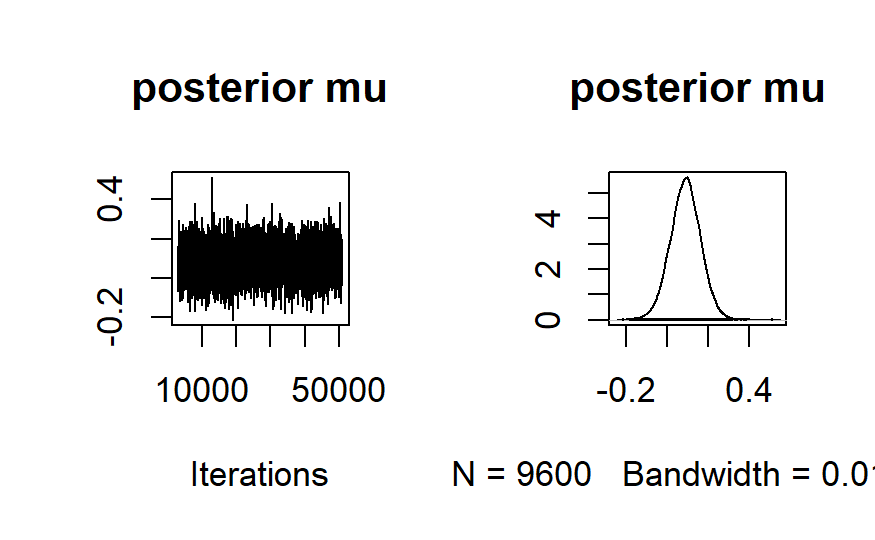

```r
# Trace and density
plot(samp_78$samples[,c('mu')], main="posterior mu")
```

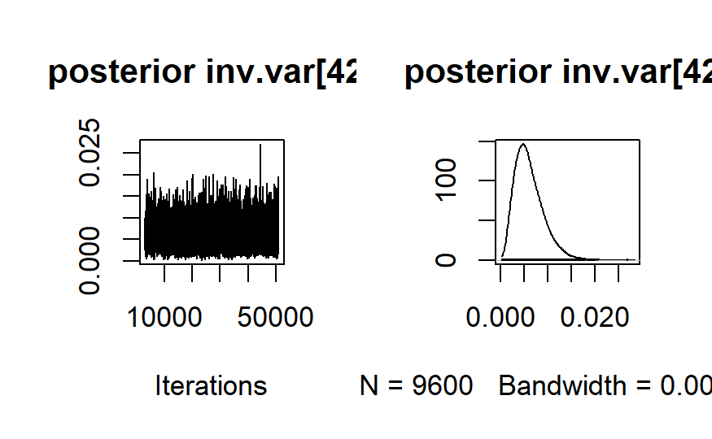

```r
plot(samp_78$samples[,c('inv.var[42]')], main="posterior inv.var[42]")
```

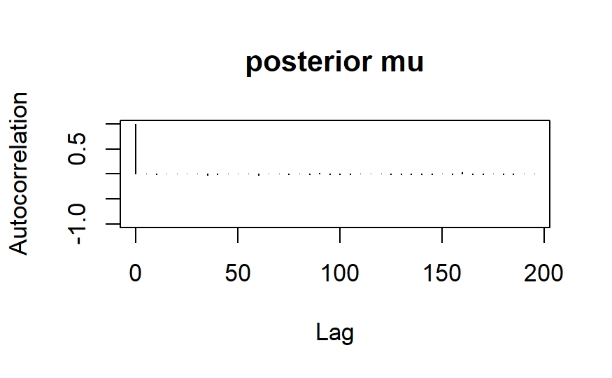

```r
# Autocorrelation
autocorr.plot(samp_78$samples[,c('mu')], main="posterior mu")
```

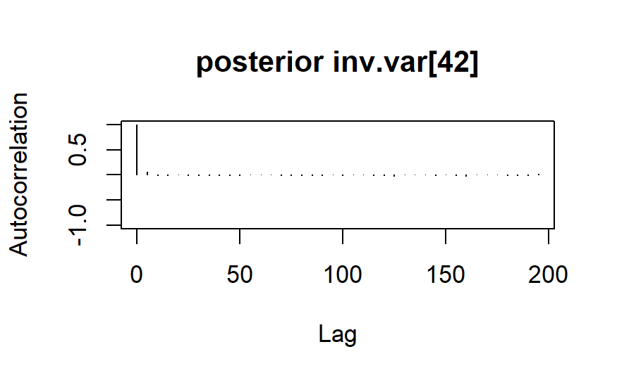

```r
autocorr.plot(samp_78$samples[,c('inv.var[42]')], main="posterior inv.var[42]")
```

We now plot the bayesian estimate of $\sigma^{-2}_t$. We can use these estimates to obtain a classification of the observations according to the value of the variance.

Here we choose to divide the variances in two classes using the latent variables $\delta_t$ (the probability of belonging to the **lower variance** group).

We may interpret the red line as periods of high volatility.

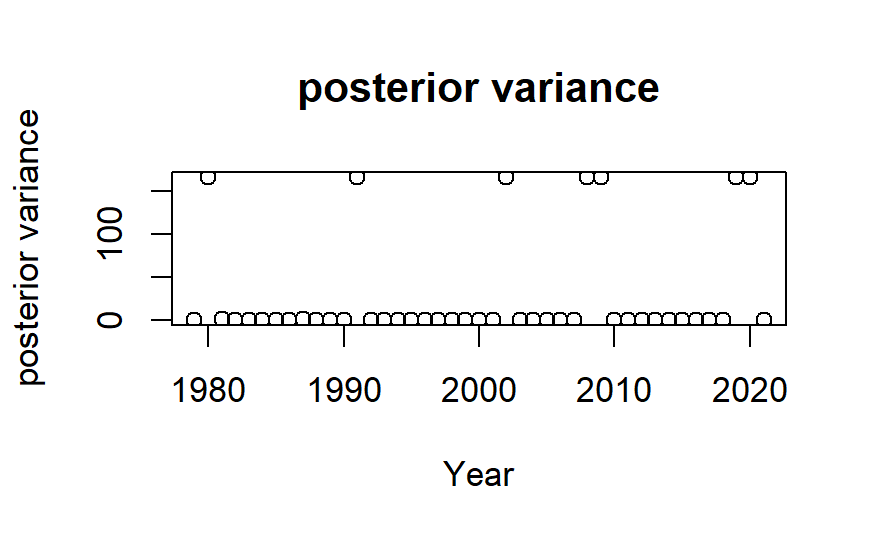

```r
# Getting inv.var and 'd[i]'
inv.var = samp_78$mean$inv.var
tauest = samp_78$mean$d        # tauest is the probability 'd[i]'


# Plotting the variance
var = 1 / inv.var
plot(year_78[1:length(delta_logdata_78_p3)], var, xlab="Year", ylab="posterior variance", main="posterior variance")
```

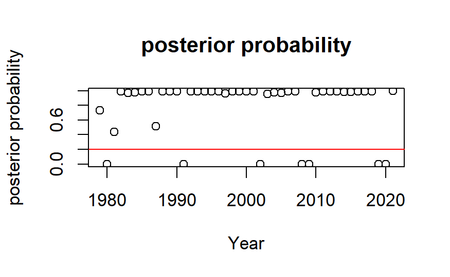

```r
# Plotting the probabilities
plot(year_78[1:length(delta_logdata_78_p3)], tauest, xlab="Year", ylab="posterior probability", main="posterior probability")
abline(h=0.2, col="red")
```

```r
# abline(h=0.25, col="orange")



# Plots 3 & 4
# Selecting the red points
ii = seq(1:length(year_78))
oo = ii[tauest < 0.2]      # Higher variance means a lower tau


# Plot in the delta log domain
plot(year_78[1:length(delta_logdata_78)], delta_logdata_78, main = "Delta log-co2 after 1978", ylab="Delta log-co2", xlab="Year")
lines(year_78[oo], delta_logdata_78[oo], type="p", col="red")
```

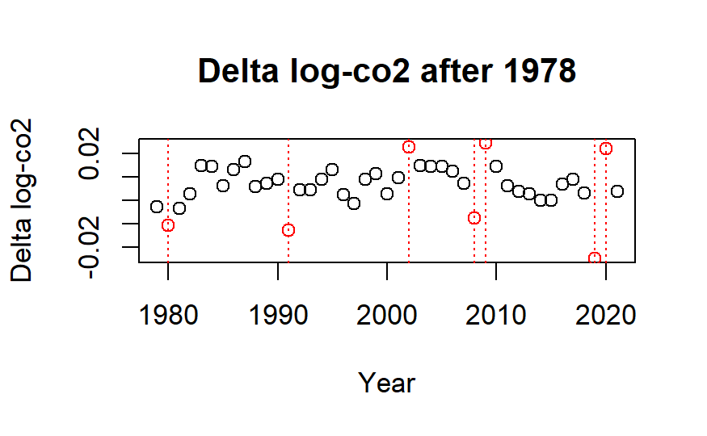

```r
# The lines / red points indicate months with high variance
for(k in oo){
  abline(v = year_78[k], col="red", lty = 3)
}
```

```r
# Plot in the AnnualCo2 domain
plot(year_78, world_data_after1978$AnnualCO2, type='l', col='darkgreen', ylab="Annual CO2 (billion t)", main="CO2 Emissions for the World", xlab="Year")
points(year_78, world_data_after1978$AnnualCO2, col='darkgreen', pch=16, cex=0.5)
```

```r
lines(year_78[oo], world_data_after1978$AnnualCO2[oo], type="p", col="red")

# The lines / red points indicate years with high variance
for(k in oo){
  abline(v=year_78[k], col="red", lty = 3)
}
```

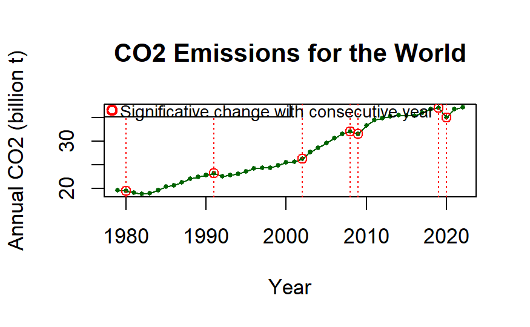

```r
# Add a legend
legend("topleft", legend="Significative change with consecutive year", pch=1, col="red", pt.cex=1, pt.lwd=2, cex=0.8)
```

```r
# We can suppose that years with high variace indicate crisis
year_78[oo]
```

```
[1] 1980 1991 2002 2008 2009 2019 2020
```

The years with the most significant variance in CO2 emission trends are: 1980, 1991, 2002, 2008, 2009, 2019, 2020.

### Before 1949

We will now repeat the same analysis for the years before 1949.

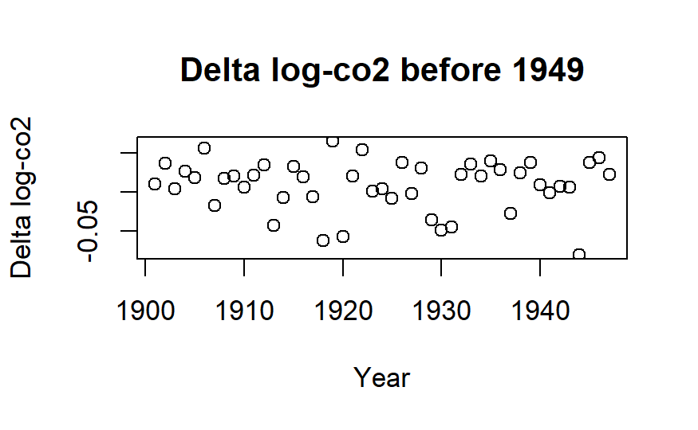

```r
# Enchancing the data
# Normalization step
mean_val <- mean(delta_logdata_49)
sd_val <- sd(delta_logdata_49)

delta_logdata_49_norm <- (delta_logdata_49 - mean_val) / sd_val


# To enhance the varability in the data we evevate it power 3
delta_logdata_49_p3 = delta_logdata_49_norm^3


# Plots
# Normal
plot(year_49[1:length(delta_logdata_49)], delta_logdata_49, ylab="Delta log-co2", main="Delta log-co2 before 1949", xlab="Year")
```

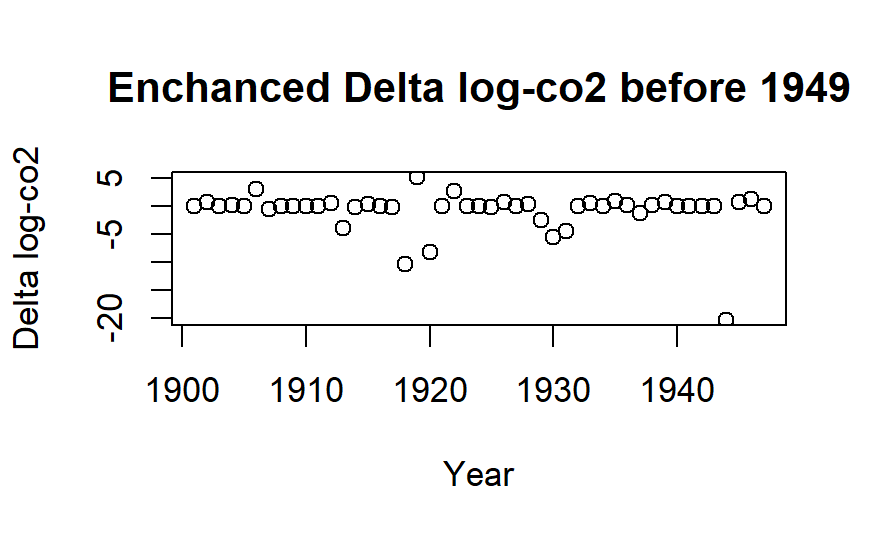

```r
# Enhanced
plot(year_49[1:length(delta_logdata_49_p3)], delta_logdata_49_p3, ylab="Delta log-co2", main="Enchanced Delta log-co2 before 1949", xlab="Year")
```

The general variance between datapoints is higher in this period. To obtain more extreme results we introduce a strong bias with respect to higher variance in the model and we change the priors to:

$$\begin{split}
& \beta_1 \sim \mathcal{E}(10) \\
& \beta_2 \sim \mathcal{E}(10) \\
& \delta_t \sim Ber(p) \\
& p \sim Beta(1,1) \\
& \mu\sim \mathcal{N}(0,10) \\
\end{split}$$

We choose the priors for $\mu$, and $p$ to be weakly informative, while for $\beta_1$ and $\beta_2$ we injected a strong bias toward values near zero (higher parameter of the exponential distribution).

Oss: We are practically telling the model that the data has high variance (as we can see from the plotted data) and it needs to learn a $\delta_t$ to classify the points with lower variance.

```r
model4.string <-"model {
  #likeliohood
  for(i in 1:N){
    x[i] ~ dnorm(mu, inv.var[i])
    inv.var[i] <- beta[1] + beta[2] * d[i]
  }

  # Prior for d[i]
  for(k in 1:N){
    d[k] ~ dbern(p)             # probabilities
  }

  # Prior for beta
    beta[1] ~ dexp(10)       # Strong prior to generate more extreme results
    beta[2] ~ dexp(10)
    # beta[1] ~ dgamma(0.001, 0.001)    # Non informative
    # beta[2] ~ dgamma(0.001, 0.001)

  # Prior for beta
   p ~ dbeta(1,1)

  # Prior for the mean
  mu   ~ dnorm(0, 0.1)
}"


# After 1978
data_49 <- list("x" = delta_logdata_49_p3, "N" = length(delta_logdata_49_p3))
samp_49 <- jags(model.file = textConnection(model4.string),
                     data=data_49,
                     parameters.to.save= c("inv.var", "d", "mu"),
                     n.adapt=1000, n.iter=50000, n.chains = 1, n.burnin = 2000,
                     n.thin = 5)
```

[output not shown]

[output cut: 117 more lines]

[output not shown]

```r
# Output
samp_49
```

```
JAGS output for model '8', generated by jagsUI.
Estimates based on 1 chains of 50000 iterations,
adaptation = 1000 iterations (sufficient),
burn-in = 2000 iterations and thin rate = 5,
yielding 9600 total samples from the joint posterior.
MCMC ran for 0.038 minutes at time 2024-06-04 18:55:48.670976.
```

|  | mean | sd | 2.5% | 50% | 97.5% | overlap0 | f |
| --- | --- | --- | --- | --- | --- | --- | --- |
| inv.var[1] | 1.097 | 0.405 | 0.022 | 1.081 | 1.927 | FALSE | 1.000 |
| inv.var[2] | 1.088 | 0.414 | 0.021 | 1.075 | 1.926 | FALSE | 1.000 |
| inv.var[3] | 1.092 | 0.410 | 0.021 | 1.078 | 1.926 | FALSE | 1.000 |
| inv.var[4] | 1.095 | 0.407 | 0.022 | 1.080 | 1.923 | FALSE | 1.000 |
| inv.var[5] | 1.091 | 0.411 | 0.020 | 1.077 | 1.922 | FALSE | 1.000 |
| inv.var[6] | 0.243 | 0.401 | 0.007 | 0.021 | 1.205 | FALSE | 1.000 |
| inv.var[7] | 1.082 | 0.419 | 0.019 | 1.072 | 1.923 | FALSE | 1.000 |
| inv.var[8] | 1.092 | 0.410 | 0.020 | 1.078 | 1.925 | FALSE | 1.000 |
| inv.var[9] | 1.097 | 0.406 | 0.022 | 1.082 | 1.926 | FALSE | 1.000 |
| inv.var[10] | 1.093 | 0.411 | 0.020 | 1.078 | 1.926 | FALSE | 1.000 |

[output cut: 86 more lines]

```
overlap0 checks if 0 falls in the parameter's 95% credible interval.
f is the proportion of the posterior with the same sign as the mean;
i.e., our confidence that the parameter is positive or negative.

DIC info: (pD = var(deviance)/2)
pD = 68.8 and DIC = 223.747
DIC is an estimate of expected predictive error (lower is better).
```

```r
# Trace and density
plot(samp_49$samples[,c('mu')], main="posterior mu")
plot(samp_49$samples[,c('inv.var[12]')], main="posterior inv.var[12]")
```

[output not shown]

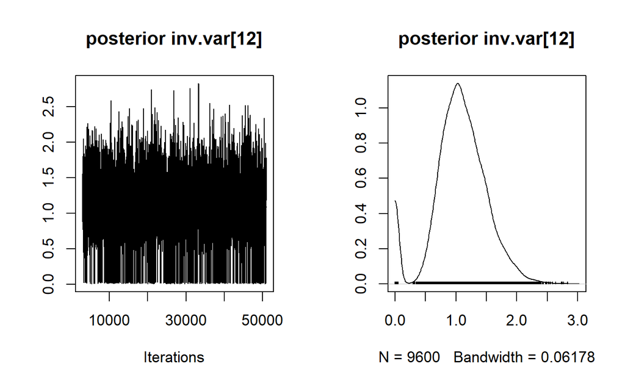

```r
# Autocorrelation
autocorr.plot(samp_49$samples[,c('mu')], main="posterior mu")
```

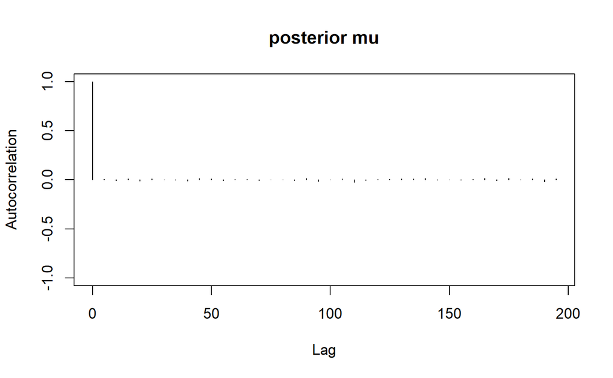

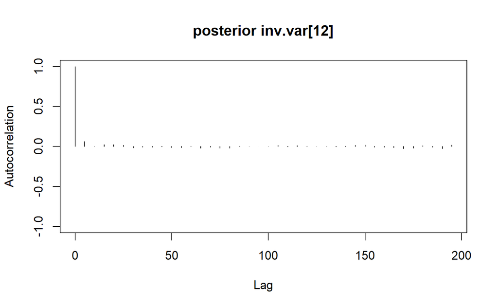

```r
autocorr.plot(samp_49$samples[,c('inv.var[12]')], main="posterior inv.var[12]")
```

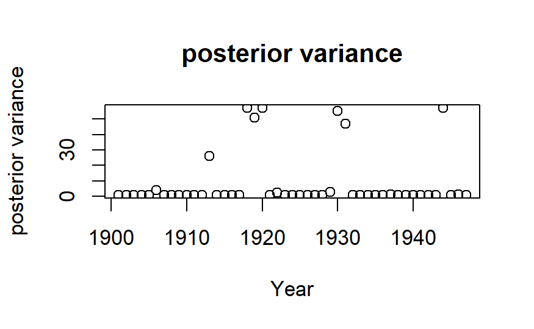

```r
# Getting inv.var and 'd[i]'
inv.var = samp_49$mean$inv.var
tauest = samp_49$mean$d        # tauest is the probability 'd[i]'


# Plotting the variance
var = 1 / inv.var
plot(year_49[1:length(delta_logdata_49_p3)], var, xlab="Year", ylab="posterior variance", main="posterior variance")
```

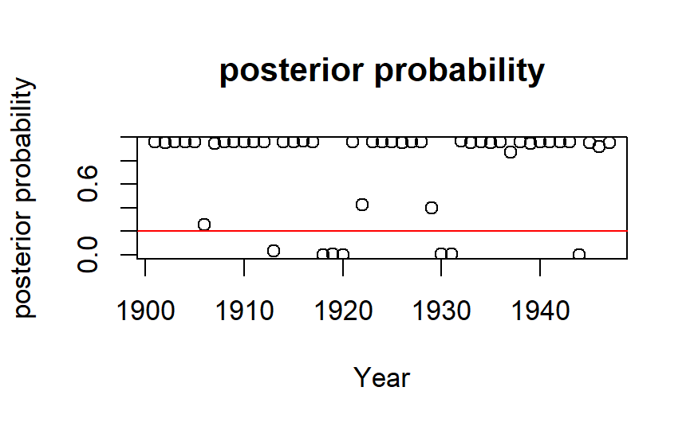

```r
# Plotting the probabilities
plot(year_49[1:length(delta_logdata_49_p3)], tauest, xlab="Year", ylab="posterior probability", main="posterior probability")
abline(h=0.2, col="red")
```

```r
# abline(h=0.25, col="orange")



# Plots 3 & 4
# Selecting the red points
ii = seq(1:length(year_49))
oo = ii[tauest < 0.2]      # Higher variance means a lower tau


# Plot in the delta log domain
plot(year_49[1:length(delta_logdata_49)], delta_logdata_49, main = "Delta log-co2 before 1949", ylab="Delta log-co2", xlab="Year")
lines(year_49[oo], delta_logdata_49[oo], type="p", col="red")
```

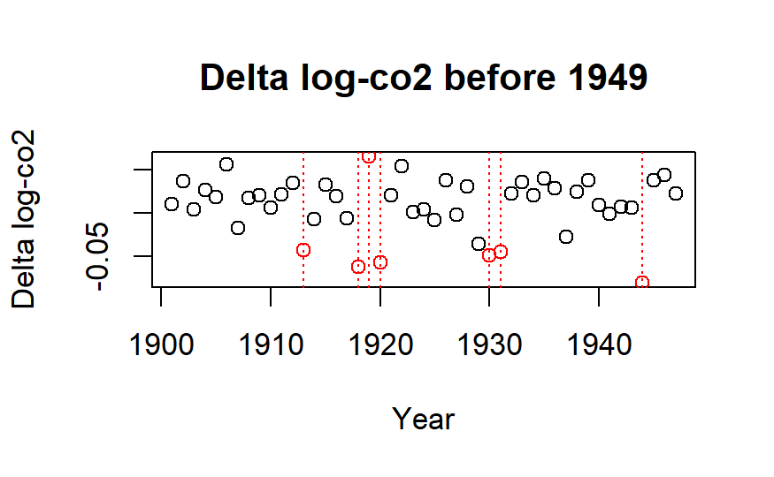

```r
# The lines / red points indicate months with high variance
for(k in oo){
  abline(v = year_49[k], col="red", lty = 3)
}
```

```r
# Plot in the AnnualCo2 domain
plot(year_49, world_data_before1949$AnnualCO2, type='l', col='darkgreen', ylab="Annual CO2 (billion t)", main="CO2 Emissions for the World", xlab="Year")
points(year_49, world_data_before1949$AnnualCO2, col='darkgreen', pch=16, cex=0.5)
```

```r
lines(year_49[oo], world_data_before1949$AnnualCO2[oo], type="p", col="red")

# The lines / red points indicate years with high variance
for(k in oo){
  abline(v=year_78[k], col="red", lty = 3)
}
```

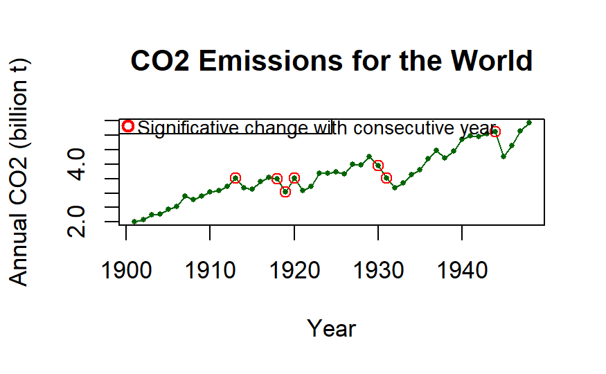

```r
# Add a legend
legend("topleft", legend="Significative change with consecutive year", pch=1, col="red", pt.cex=1, pt.lwd=2, cex=0.8)
```

```r
# We can suppose that years with high variace indicate crisis
year_49[oo]
```

```
[1] 1913 1918 1919 1920 1930 1931 1944
```

The years with the most significant variance in CO2 emission trends are: 1913, 1918 ,1919, 1920, 1930, 1931, 1944.

Those years indicate periods where the subsequent year experienced a noticeable change in CO2 emissions (we analysed the delta of the data) and can be directly linked with major global economic phenomena:

- 1913: **Beginning of World War I** (1914)
- 1918/1919/1920: **End of World War I** (1918) and aftermath
- 1930/1931: **The Great Depression** (1929–1939)
- 1944: **End of World War II** (1945)

**Disclaimer:** The years between 1900 and 1945 were troubled and a lot of significant events happened in that period. This makes the general variability between each year more accentuated and as such significant events are harder to spot.

```r
#
```

# Dataset 2

We will continue our analysis by analyzing the impact of various factors on CO2 emissions in recent years.

**Sources:**

https://ourworldindata.org/grapher/energy-use-per-capita-vs-gdp-per-capita

https://ourworldindata.org/grapher/co2-emissions-vs-gdp

https://ourworldindata.org/grapher/low-carbon-energy-consumption?country=OMN

https://ourworldindata.org/grapher/urbanization-vs-gdp

https://ourworldindata.org/grapher/number-of-internet-users-by-country

**Short description:**

- **country**: name of the country.
- **y**: year.
- **EnergyUse**: Energy use [kg of oil equivalent per capita].
- **GDP**: Gross Domestic Product per capita. [1$ per capita]
- **pop**: Population (historical estimates).
- **co2percap**: Annual CO2 emissions per capita. [tons per capita]
- **Lowcarbon_energy**: Low-carbon energy (% sub energy). Low-carbon energy is de fined as the sum of nuclear and renewable sources. Renewable sources include hydropower, solar, wind, geothermal, wave and tidal and bioenergy. Traditional biofuels are not included.
- **urb**: urban population (%) .
- **internet**: number of internet users (OWID based on WB & UN).

## Transformations to the original dataset

To facilitate our analysis we will apply some transformations to the data.

The final structure will be the following:

- **country**: name of the country.
- **y**: year.
- **EnergyUse**: Energy use [tons of oil equivalent per capita].
- **GDP**: Gross Domestic Product per capita. [1000$ per capita]
- **pop**: Population (historical estimates). [milions people]
- **co2percap**: Annual CO2 emissions per capita. [tons per capita]
- **Lowcarbon_energy**: Low-carbon energy (% sub energy). Low-carbon energy is de fined as the sum of nuclear and renewable sources. Renewable sources include hydropower, solar, wind, geothermal, wave and tidal and bioenergy. Traditional biofuels are not included.
- **urb**: urban population. [%]
- **internet**: number of internet users (OWID based on WB & UN).
- **internet_users_ratio**: ratio of internet users over the total population.

```r
rm(list=ls())

library(rjags)
library(bayesplot)
library(jagsUI)
library(loo)
# Loading the data
CO2 <- read.csv("Data/CO2.csv")
# Removing the 'World' datapoints
CO2 <- CO2[CO2$country != 'World',]
head(CO2)
```

|  | X | country | y | EnergyUse | GDP | pop | co2percap | Lowcarbon_energy | internet | urb |
| --- | --- | --- | --- | --- | --- | --- | --- | --- | --- | --- |
| 1 | 6 | Algeria | 2005 | 11373.607 | 10504.858 | 33149720 | 3.2119 | 0.408 | 1945357 | 63.830 |
| 2 | 13 | Argentina | 2005 | 20011.439 | 19426.440 | 38892924 | 4.1507 | 15.966 | 6936809 | 90.031 |
| 3 | 19 | Australia | 2005 | 64710.334 | 42217.136 | 20178543 | 19.2086 | 4.010 | 12750509 | 84.582 |
| 4 | 21 | Austria | 2005 | 47515.152 | 49316.265 | 8253656 | 9.5797 | 26.583 | 4787117 | 58.813 |
| 5 | 22 | Azerbaijan | 2005 | 18607.543 | 7222.036 | 8538610 | 4.0155 | 4.872 | 685682 | 52.389 |
| 6 | 25 | Bangladesh | 2005 | 1906.654 | 2279.531 | 139035505 | 0.2710 | 1.067 | 346583 | 26.809 |

```r
summary(CO2)
```

```
       X            country                y          EnergyUse           GDP              pop
 Min.   :   6.0   Length:359         Min.   :2005   Min.   :  1907   Min.   :  2280   Min.   :2.950e+05
 1st Qu.: 287.5   Class :character   1st Qu.:2006   1st Qu.: 17651   1st Qu.: 11415   1st Qu.:6.028e+06
 Median :1341.0   Mode  :character   Median :2007   Median : 31897   Median : 23103   Median :2.018e+07
 Mean   :1397.1                      Mean   :2007   Mean   : 37667   Mean   : 28101   Mean   :7.639e+07
 3rd Qu.:2452.5                      3rd Qu.:2008   3rd Qu.: 47482   3rd Qu.: 43062   3rd Qu.:6.169e+07
 Max.   :3294.0                      Max.   :2009   Max.   :196676   Max.   :114889   Max.   :1.361e+09
   co2percap      Lowcarbon_energy    internet              urb
 Min.   : 0.271   Min.   : 0.001   Min.   :    47416   Min.   : 18.24
 1st Qu.: 3.920   1st Qu.: 2.957   1st Qu.:  2143640   1st Qu.: 55.49
 Median : 6.823   Median :11.868   Median :  5145879   Median : 68.50
 Mean   : 7.617   Mean   :15.362   Mean   : 17773004   Mean   : 67.42
 3rd Qu.:10.060   3rd Qu.:19.113   3rd Qu.: 14756650   3rd Qu.: 80.53
 Max.   :34.571   Max.   :81.746   Max.   :390747678   Max.   :100.00
```

```r
# Calculate the ratio of internet users to population
CO2$internet_users_ratio = CO2$internet / CO2$pop * 100
# Rescaling some data
CO2$GDP = CO2$GDP / 1000
CO2$EnergyUse = CO2$EnergyUse / 1000
CO2$pop = CO2$pop / 1000000



# Colour palette
library(RColorBrewer)
num_countries <- length(unique(CO2$country))
palette_colors <- colorRampPalette(brewer.pal(12, "Set1"))(num_countries)
```

[output not shown]

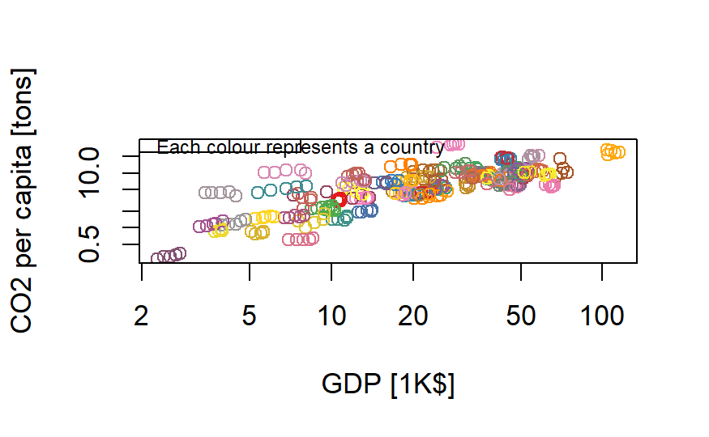

```r
# Plotting the data by country
plot(CO2$GDP, CO2$co2percap,
     xlab = "GDP [1K$]", ylab = "CO2 per capita [tons]",
     log = "xy",
     col = palette_colors[as.numeric(factor(CO2$country))]
     )


legend("topleft", legend="Each colour represents a country", cex=0.7)
```

## Density & Exploratory data analysis

We start our analysis by plotting the densities and visually representing the data in relation to CO2 emissions. This preliminary examination helps us understand the distribution and relationships within the data.

[output not shown]

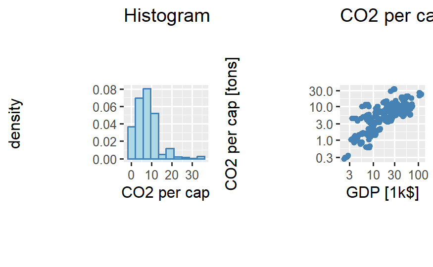

```r
library(ggplot2)
library(gridExtra)
plot_hist_scatter <- function(data, hist_var, scatter_var_x, scatter_var_y,
                              name_hist_var, name_x, name_y, unit_x, unit_y,
                              log_scale = FALSE, bins = 20)
{
  # Plot histogram
  hist =
    ggplot(data=data, aes_string(x=hist_var)) +
    geom_histogram(aes(y=after_stat(density)), color='steelblue',
                   fill='lightblue', bins = bins) +
    ggtitle(paste("Histogram of", name_hist_var)) +
    xlab(name_hist_var)
    ylab("Density")

  # Plot scatter plot
  scatter =
    ggplot(data=data, aes_string(x=scatter_var_x, y=scatter_var_y)) +
    geom_point(color='steelblue') +
    ggtitle(paste(name_y, "vs.", name_x)) +
    xlab(paste(name_x, unit_x)) +
    ylab(paste(name_y, unit_y))


  # Apply logarithmic scale if log_scale is TRUE
  if (log_scale) {
    scatter = scatter + scale_x_log10() + scale_y_log10() + ggtitle(paste(name_y,
                "vs.",name_x, "(log scale)"))
  }

  # Arrange plots
  gridExtra::grid.arrange(hist, scatter, ncol=2)
}


# Plots
plot_hist_scatter(CO2, hist_var="co2percap", "GDP", "co2percap", name_hist_var= "CO2 per cap", name_x="GDP", name_y="CO2 per cap", unit_x="[1k$]", unit_y="[tons]", bins = 10, log_scale = TRUE)
```

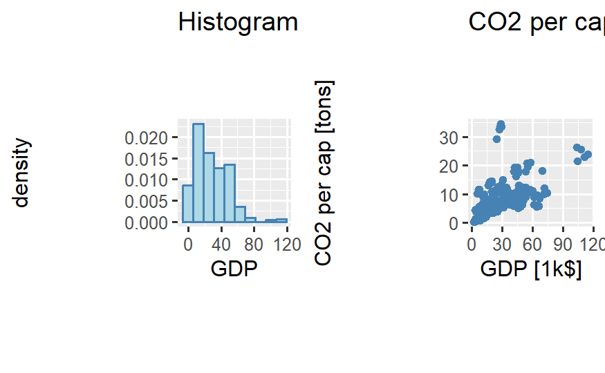

```r
plot_hist_scatter(CO2, hist_var="GDP", "GDP", "co2percap", name_hist_var="GDP", name_x="GDP", name_y="CO2 per cap", unit_x="[1k$]", unit_y="[tons]", bins = 10)
```

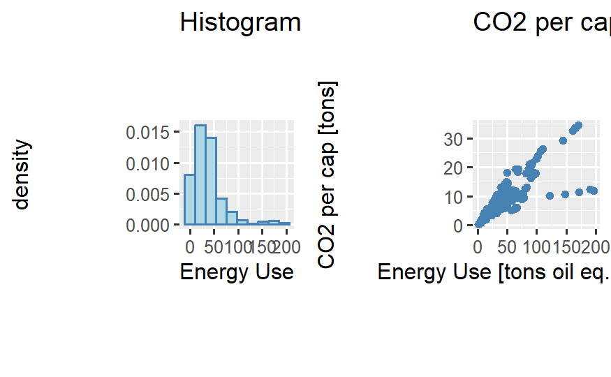

```r
plot_hist_scatter(CO2, hist_var="EnergyUse", "EnergyUse", "co2percap", name_hist_var="Energy Use", name_x="Energy Use", name_y="CO2 per cap", unit_x="[tons oil eq. per cap]", unit_y="[tons]", bins = 10)
```

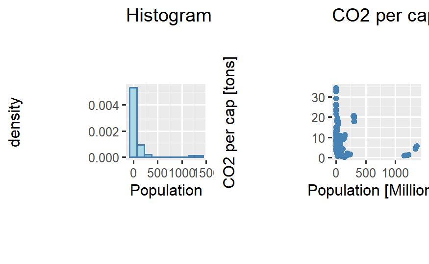

```r
plot_hist_scatter(CO2, hist_var="pop", "pop", "co2percap", name_hist_var="Population", name_x="Population", name_y="CO2 per cap", unit_x="[Millions]", unit_y="[tons]", bins = 10)
```

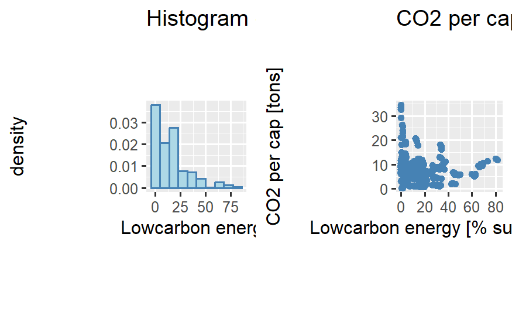

```r
plot_hist_scatter(CO2, hist_var="Lowcarbon_energy", "Lowcarbon_energy", "co2percap", name_hist_var="Lowcarbon energy", name_x="Lowcarbon energy", name_y="CO2 per cap", unit_x="[% sub energy]", unit_y="[tons]", bins = 10)
```

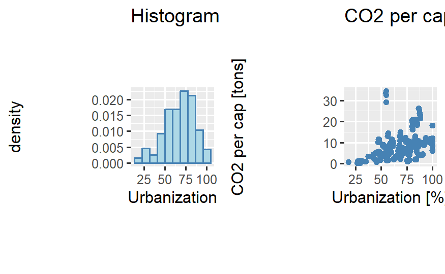

```r
plot_hist_scatter(CO2, hist_var="urb", "urb", "co2percap", name_hist_var="Urbanization", name_x="Urbanization", name_y="CO2 per cap", unit_x="[%]", unit_y="[tons]", bins = 10)
```

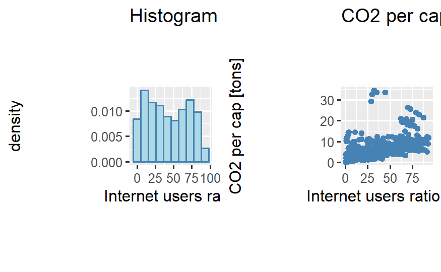

```r
plot_hist_scatter(CO2, hist_var="internet_users_ratio", "internet_users_ratio", "co2percap", name_hist_var="Internet users ratio", name_x="Internet users ratio", name_y="CO2 per cap", unit_x="[%]", unit_y="[tons]", bins = 10)
```

## Correlation Analysis

In this section, we examine the correlations between various covariates.

```r
# Create a subset of the data removing the unused covariates
CO2_subset <- CO2[, c("EnergyUse", "GDP", "pop", "co2percap", "Lowcarbon_energy", "urb", "internet_users_ratio")]

head(CO2)
```

|  | X | country | y | EnergyUse | GDP | pop | co2percap | Lowcarbon_energy | internet | urb | internet_users_ratio |
| --- | --- | --- | --- | --- | --- | --- | --- | --- | --- | --- | --- |
| 1 | 6 | Algeria | 2005 | 11.373607 | 10.504858 | 33.149720 | 3.2119 | 0.408 | 1945357 | 63.830 | 5.8683965 |
| 2 | 13 | Argentina | 2005 | 20.011439 | 19.426440 | 38.892924 | 4.1507 | 15.966 | 6936809 | 90.031 | 17.8356582 |
| 3 | 19 | Australia | 2005 | 64.710334 | 42.217136 | 20.178543 | 19.2086 | 4.010 | 12750509 | 84.582 | 63.1884522 |
| 4 | 21 | Austria | 2005 | 47.515152 | 49.316265 | 8.253656 | 9.5797 | 26.583 | 4787117 | 58.813 | 57.9999578 |
| 5 | 22 | Azerbaijan | 2005 | 18.607543 | 7.222036 | 8.538610 | 4.0155 | 4.872 | 685682 | 52.389 | 8.0303703 |
| 6 | 25 | Bangladesh | 2005 | 1.906654 | 2.279531 | 139.035505 | 0.2710 | 1.067 | 346583 | 26.809 | 0.2492766 |

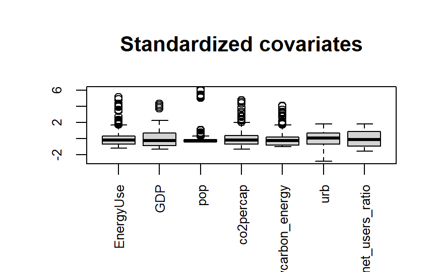

```r
# Boxplots:
par(mfrow=c(1, 1), pty="m")
boxplot(scale(CO2_subset), las=3, main="Standardized covariates", cex.axis=0.75)

# Correlation matrix:
par(mfrow=c(1, 1), pty="s")
```

```r
image(1:ncol(CO2_subset), 1:ncol(CO2_subset), cor(CO2_subset),
      xlab="", ylab="", main="Correlation between predictors",
      axes=FALSE)
axis(1,1:ncol(CO2_subset), colnames(CO2_subset), las=2,cex.axis=0.9)
```

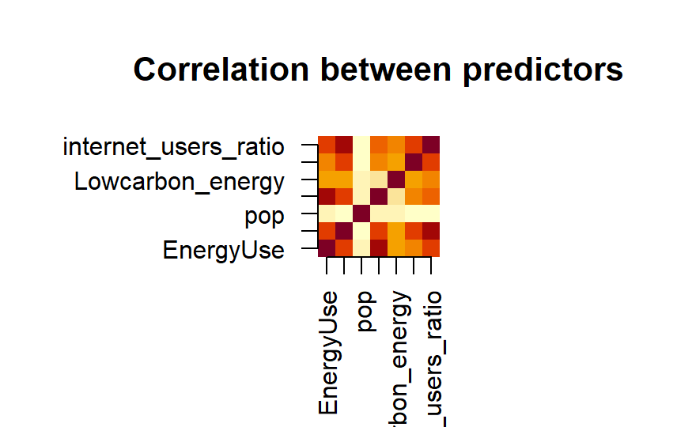

```r
axis(2,1:ncol(CO2_subset), colnames(CO2_subset), las=2,cex.axis=0.9)
```

The features with the highest correlation with CO2 emissions per capita (co2percap) are EnergyUse, GDP, and internet_user_ratio.

## *Spike and slab prior*

To determine the most impactful variables for our analysis, and perform varaible selection, we will employ a Bayesian approach using the Spike-and-Slab prior on the normalized data.

The spike & slab prior for a linear regression model is

$$\begin{align*}
\beta_j \mid \gamma_j &\overset{ind}\sim (1-\gamma_j)\,\delta_{(0)}
+ \gamma_j\,\mathcal{N}\left(0, \sigma^2_{\beta_j}\right), \\
\gamma_j \mid \theta_j &\overset{ind}\sim
\mathcal{B}e\left(\theta_j\right), \\[5pt]
\theta_{j} &\overset{iid}\sim p\left(\theta_j\right), \end{align*}$$

where $\theta_j$ is a probability which determines whether $\beta_j$ is nonzero and hence whether the corresponding covariate will be included in the model , $\sigma^2_{\beta_j} = 1$ and $p(\theta_j)$ is a uniform distribution.

```r
library(rjags)

head(CO2_subset)
```

|  | EnergyUse | GDP | pop | co2percap | Lowcarbon_energy | urb | internet_users_ratio |
| --- | --- | --- | --- | --- | --- | --- | --- |
| 1 | 11.373607 | 10.504858 | 33.149720 | 3.2119 | 0.408 | 63.830 | 5.8683965 |
| 2 | 20.011439 | 19.426440 | 38.892924 | 4.1507 | 15.966 | 90.031 | 17.8356582 |
| 3 | 64.710334 | 42.217136 | 20.178543 | 19.2086 | 4.010 | 84.582 | 63.1884522 |
| 4 | 47.515152 | 49.316265 | 8.253656 | 9.5797 | 26.583 | 58.813 | 57.9999578 |
| 5 | 18.607543 | 7.222036 | 8.538610 | 4.0155 | 4.872 | 52.389 | 8.0303703 |
| 6 | 1.906654 | 2.279531 | 139.035505 | 0.2710 | 1.067 | 26.809 | 0.2492766 |

```r
# Spike and slab model
```

```r
model_string = textConnection(
"model {
  # Likelihood
  for (i in 1:N) {
    Y[i] ~ dnorm(beta0 + inprod(X[i,], beta[]), inv.var.y)
  }

  # Priors
  inv.var.y ~ dgamma(0.01, 0.01)
  beta0 ~ dnorm(0, 0.001)

  for(j in 1:P) {
    inv_var_beta[j] = 1 / var_beta[j]
  }

  for(j in 1:P) {
    beta[j] = g[j] * betaTemp[j]
    betaTemp[j] ~ dnorm(0, inv_var_beta[j])

    g[j] ~ dbern(theta[j])
    theta[j] ~ dunif(0, 1)
  }

}")


# Model settings:
Y = CO2_subset$co2percap

# We standardise the data to help the algorithm
X = within(CO2_subset, rm("co2percap"))
X_norm = scale(X)                         # Standardization step
P = ncol(X)
N = nrow(X)

# Data:
var_beta=rep(1, P)
dataList = list(Y=Y, X=X_norm, var_beta=var_beta, N=N, P=P)


# Specify the initial values:
inits = list(beta0=0, betaTemp=rep(0,P), g=rep(0,P), theta=rep(0.5,P))


# Jags 2
samples <- jags(model.file = model_string,
                     data=dataList,
                     # inits=inits,
                     parameters.to.save= c("beta0", "beta", "g"),
                     n.adapt=1000, n.iter=20000, n.chains = 3, n.burnin = 5000,
                     n.thin = 2)
```

[output not shown]

[output cut: 66 more lines]

[output not shown]

```r
# Output
samples
```

```
JAGS output for model '7', generated by jagsUI.
Estimates based on 3 chains of 20000 iterations,
adaptation = 1000 iterations (sufficient),
burn-in = 5000 iterations and thin rate = 2,
yielding 22500 total samples from the joint posterior.
MCMC ran for 0.34 minutes at time 2024-06-16 15:58:28.932887.
```

|  | mean | sd | 2.5% | 50% | 97.5% | overlap0 | f | Rhat | n.eff |
| --- | --- | --- | --- | --- | --- | --- | --- | --- | --- |
| beta0 | 7.617 | 0.107 | 7.405 | 7.616 | 7.826 | FALSE | 1.000 | 1.001 | 3950 |
| beta[1] | 4.754 | 0.139 | 4.483 | 4.753 | 5.025 | FALSE | 1.000 | 1.000 | 11731 |
| beta[2] | 1.069 | 0.153 | 0.763 | 1.071 | 1.364 | FALSE | 1.000 | 1.000 | 22500 |
| beta[3] | -0.006 | 0.040 | -0.134 | 0.000 | 0.027 | TRUE | 0.074 | 1.001 | 14925 |
| beta[4] | -2.263 | 0.115 | -2.487 | -2.263 | -2.038 | FALSE | 1.000 | 1.000 | 22500 |
| beta[5] | 0.008 | 0.054 | -0.057 | 0.000 | 0.182 | TRUE | 0.957 | 1.001 | 22500 |
| beta[6] | 0.009 | 0.086 | -0.158 | 0.000 | 0.267 | TRUE | 0.932 | 1.001 | 12027 |
| g[1] | 1.000 | 0.000 | 1.000 | 1.000 | 1.000 | FALSE | 1.000 | NA | 1 |
| g[2] | 1.000 | 0.000 | 1.000 | 1.000 | 1.000 | FALSE | 1.000 | NA | 1 |
| g[3] | 0.108 | 0.310 | 0.000 | 0.000 | 1.000 | TRUE | 1.000 | 1.000 | 22500 |

[output cut: 4 more lines]

```
**WARNING** Some Rhat values could not be calculated.
Successful convergence based on Rhat values (all < 1.1).
Rhat is the potential scale reduction factor (at convergence, Rhat=1).
For each parameter, n.eff is a crude measure of effective sample size.

overlap0 checks if 0 falls in the parameter's 95% credible interval.
f is the proportion of the posterior with the same sign as the mean;
i.e., our confidence that the parameter is positive or negative.

DIC info: (pD = var(deviance)/2)
pD = 6.5 and DIC = 1533.112
DIC is an estimate of expected predictive error (lower is better).
```

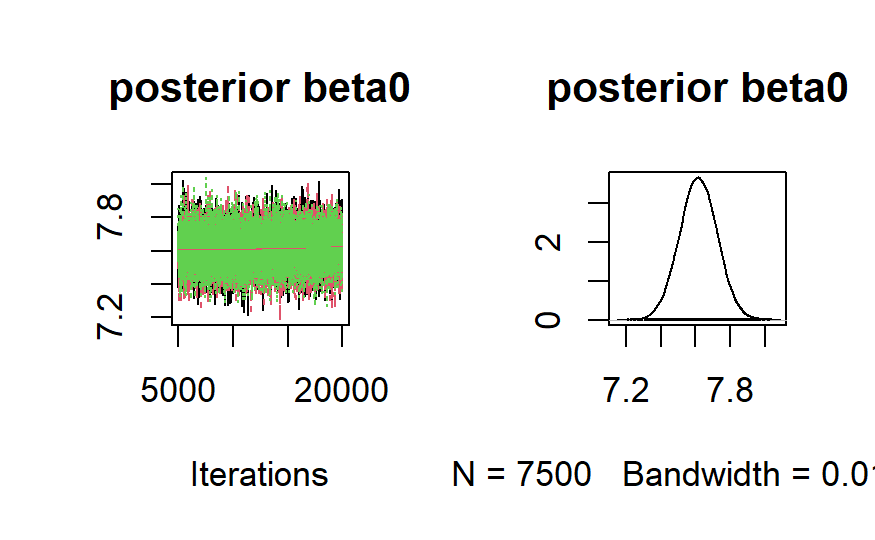

```r
# Trace and density
# beta0
plot(samples$samples[,c('beta0')], main="posterior beta0")
```

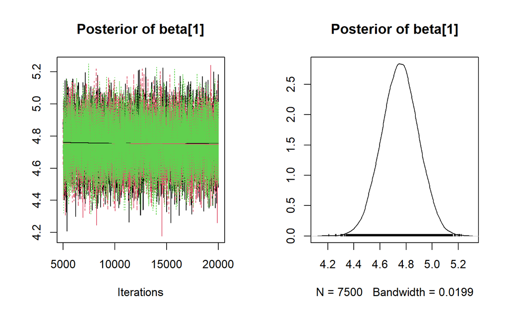

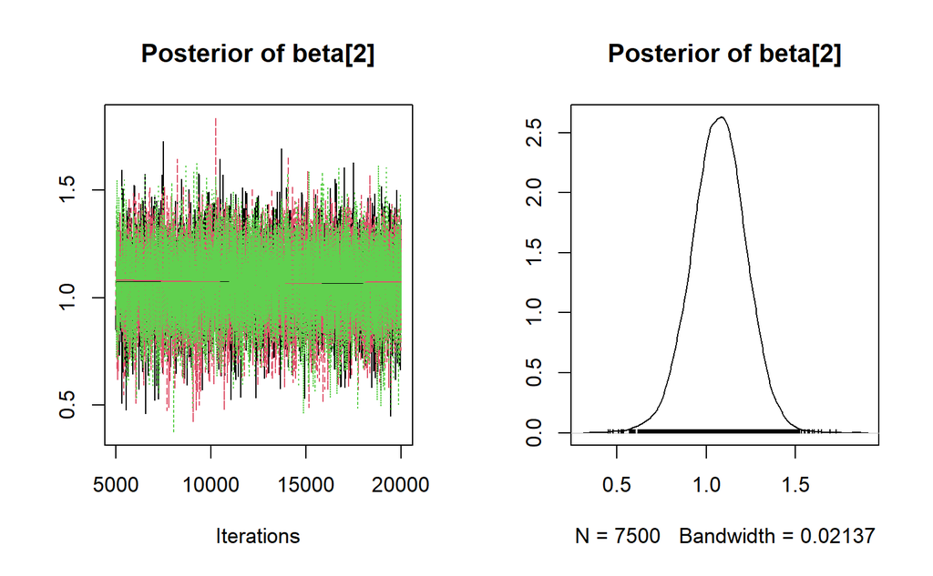

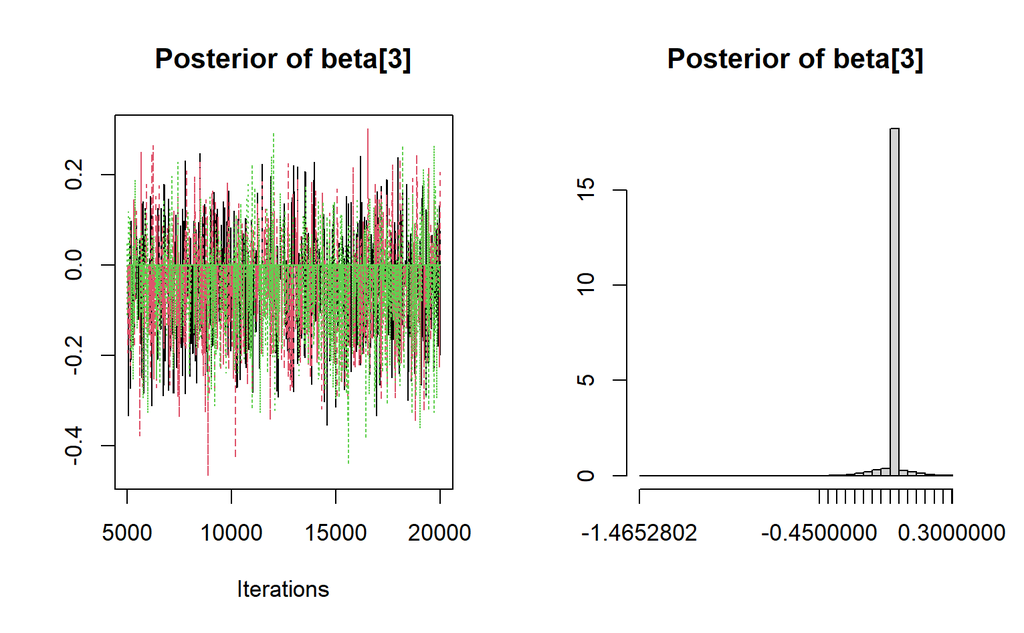

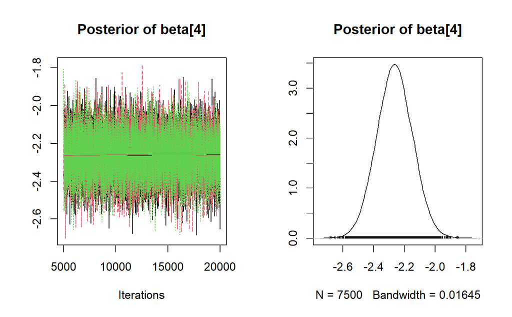

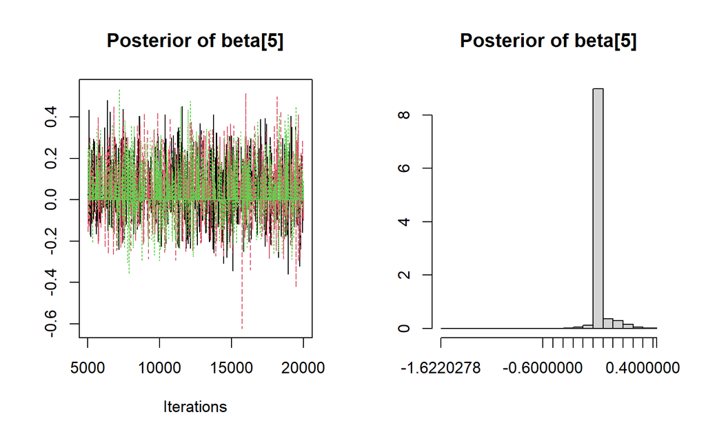

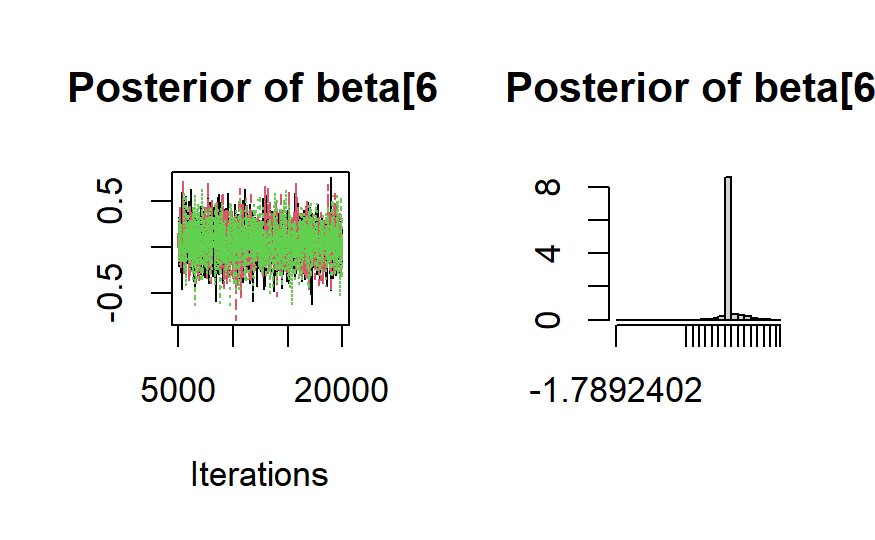

```r
# beta[i]
for(k in 1:P){
  param_name <- paste0("beta[", k, "]")  # Construct the parameter name dynamically
  plot(samples$samples[, param_name], main = paste("Posterior of", param_name))
}
```

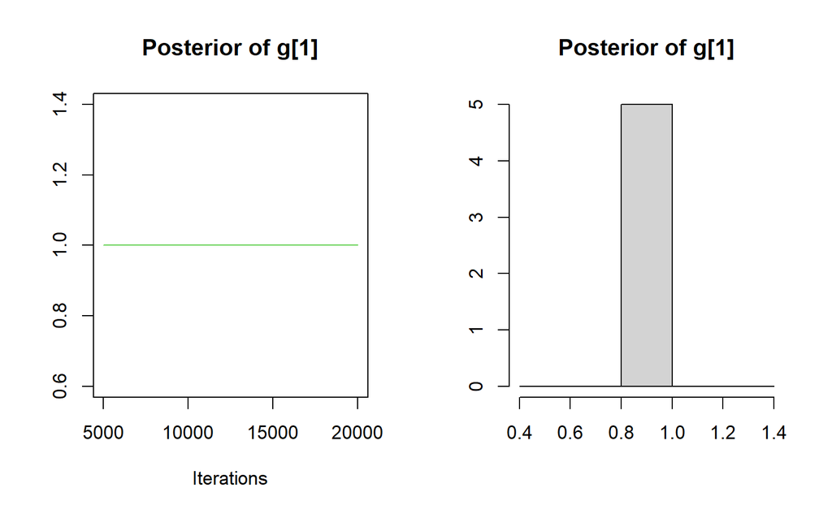

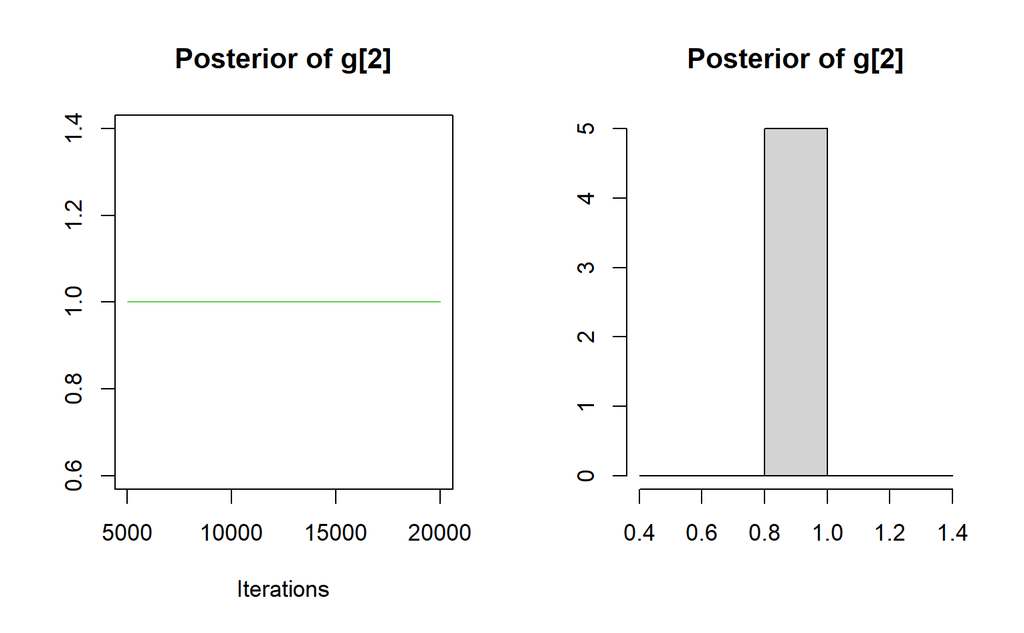

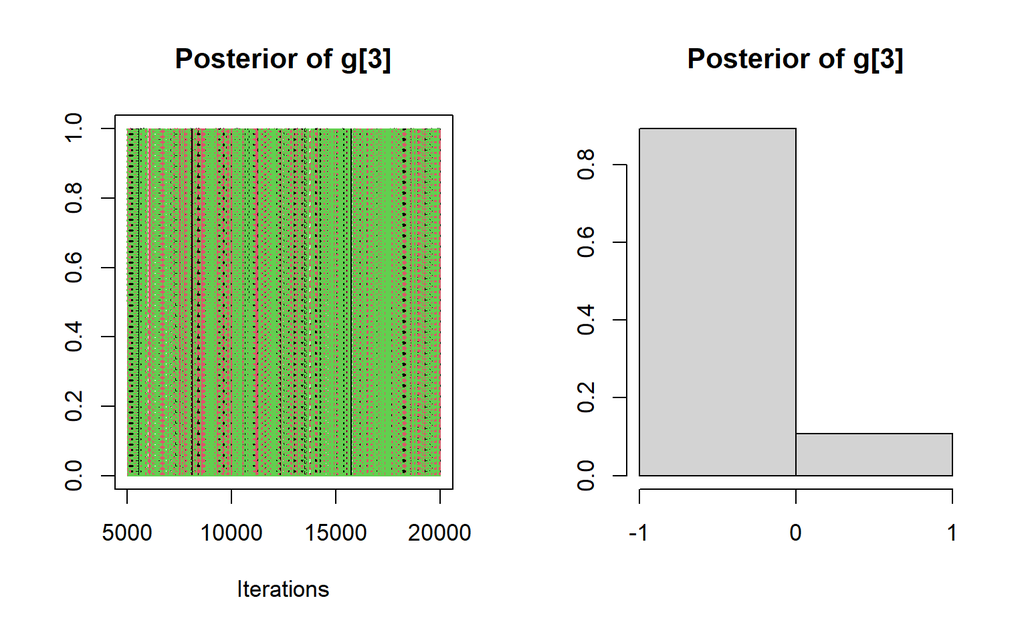

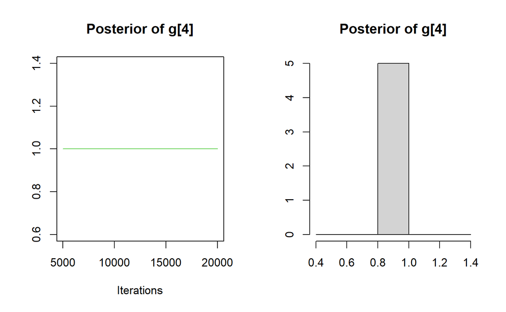

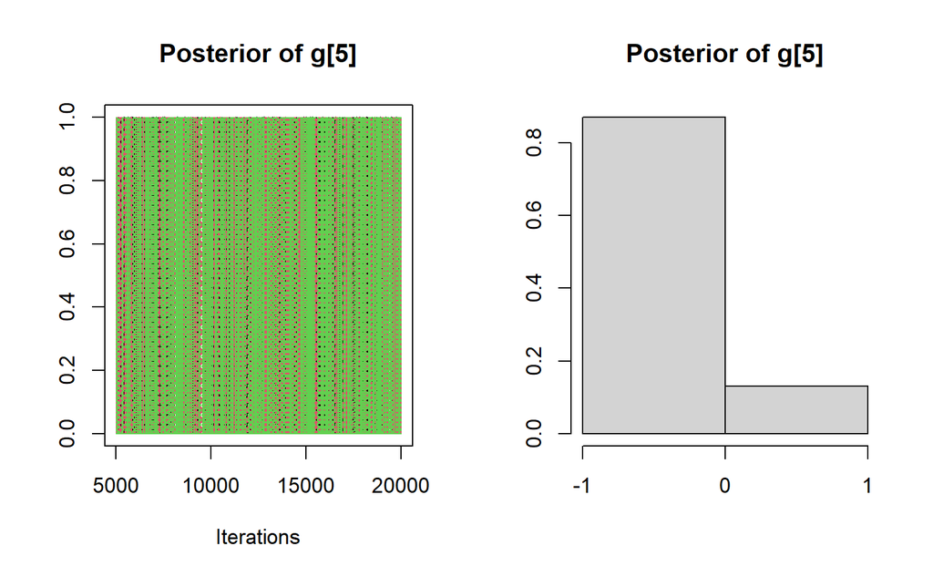

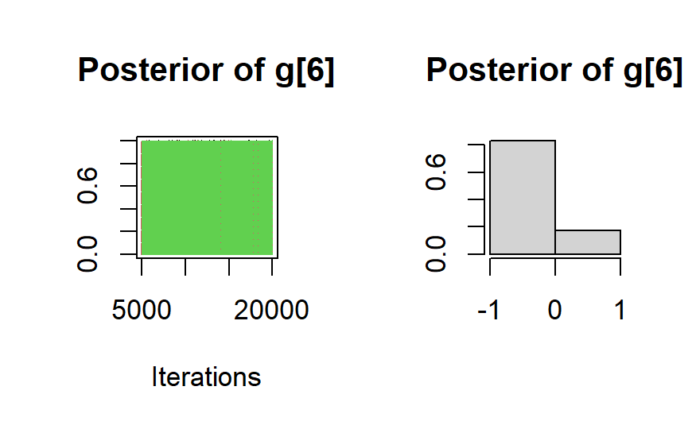

```r
# g[i]
for(k in 1:P){
  param_name <- paste0("g[", k, "]")  # Construct the parameter name dynamically
  plot(samples$samples[, param_name], main = paste("Posterior of", param_name))
}
```

Here we can visualize the **posterior probability of inclusion** that corresponds to the posterior mean of the $\gamma_j$, which are called **`g`** in the code.

```r
ss = summary(samples)
post_mean_g = ss[8:13, "mean"]
post_mean_g
```

```
     g[1]      g[2]      g[3]      g[4]      g[5]      g[6]
1.0000000 1.0000000 0.1080000 1.0000000 0.1295111 0.1720000
```

We can visualize them with a nice chart.

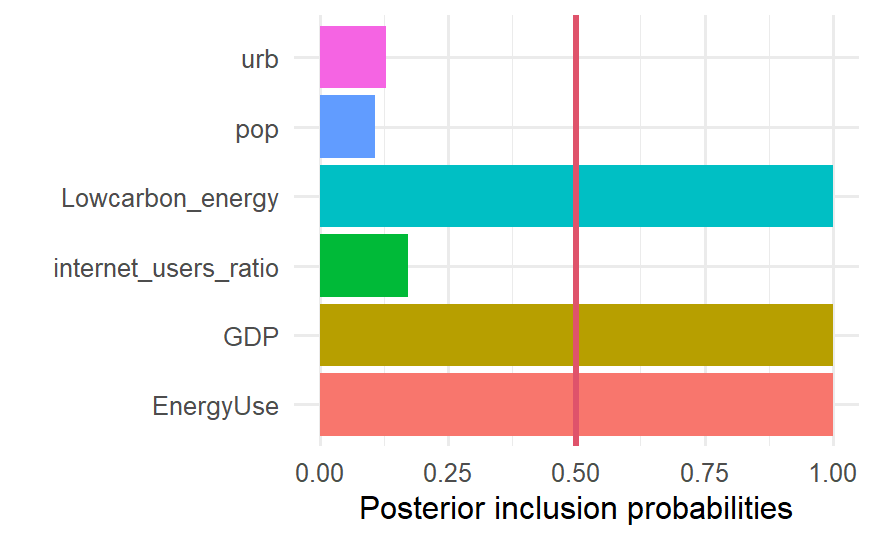

```r
# Load the library:
library(ggplot2)

postmeang_df = data.frame(value=post_mean_g, var=colnames(X))
p1 = ggplot(data=postmeang_df, aes(y=value,x=var,fill=var)) +
  geom_bar(stat="identity") +
  geom_hline(mapping=aes(yintercept=0.5), col=2, lwd=1.1) +
  coord_flip() + theme_minimal() + theme(legend.position="none") +
  ylab("Posterior inclusion probabilities") + xlab("")
p1
```

The posterior probability of inclusion plot reveals some interesting results. The model shows a strong preference, assigning a probability of 1 to Lowcarbon_energy, GDP, and EnergyUse, while assigning near-zero probabilities to urbanization, population, and internet_user_ratio.

These results are interesting. While the high inclusion probabilities for GDP and EnergyUse are consistent with their strong correlation with co2percap, the high probability for **Lowcarbon_energy** is surprising given its **low correlation** with co2percap.

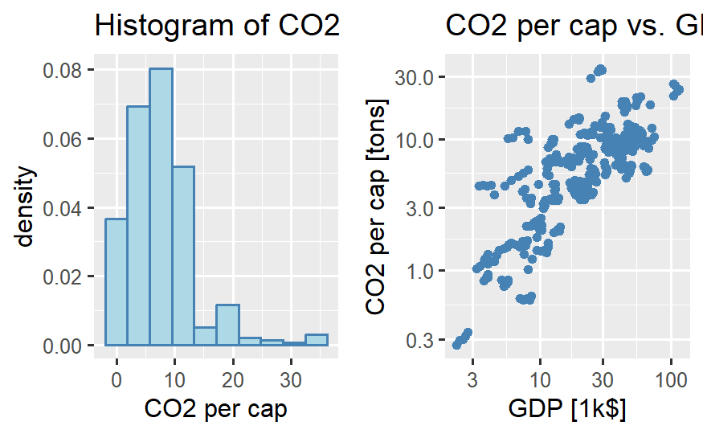

```r
plot_hist_scatter(CO2, hist_var="co2percap", "GDP", "co2percap", name_hist_var= "CO2 per cap", name_x="GDP", name_y="CO2 per cap", unit_x="[1k$]", unit_y="[tons]", bins = 10, log_scale = TRUE)
```

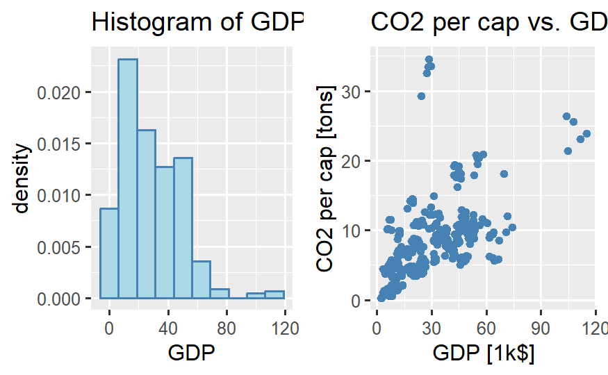

```r
plot_hist_scatter(CO2, hist_var="GDP", "GDP", "co2percap", name_hist_var="GDP", name_x="GDP", name_y="CO2 per cap", unit_x="[1k$]", unit_y="[tons]", bins = 10)
```

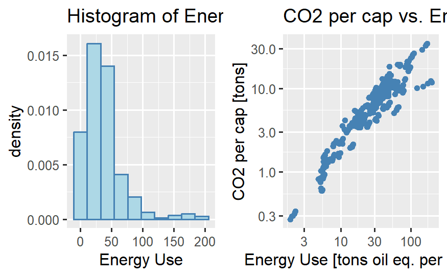

```r
plot_hist_scatter(CO2, hist_var="EnergyUse", "EnergyUse", "co2percap", name_hist_var="Energy Use", name_x="Energy Use", name_y="CO2 per cap", unit_x="[tons oil eq. per cap]", unit_y="[tons]", bins = 10, log_scale = TRUE)
```

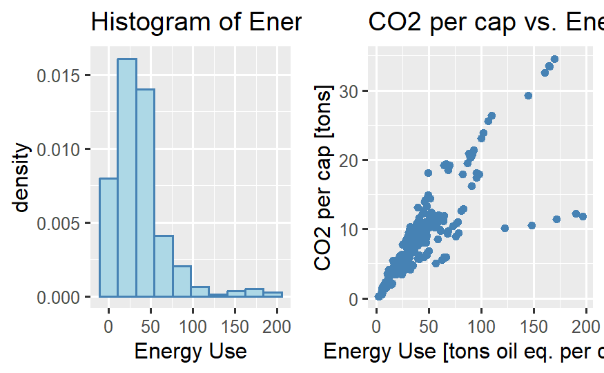

```r
plot_hist_scatter(CO2, hist_var="EnergyUse", "EnergyUse", "co2percap", name_hist_var="Energy Use", name_x="Energy Use", name_y="CO2 per cap", unit_x="[tons oil eq. per cap]", unit_y="[tons]", bins = 10)
```

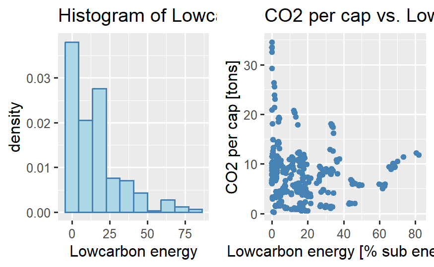

```r
plot_hist_scatter(CO2, hist_var="Lowcarbon_energy", "Lowcarbon_energy", "co2percap", name_hist_var="Lowcarbon energy", name_x="Lowcarbon energy", name_y="CO2 per cap", unit_x="[% sub energy]", unit_y="[tons]", bins = 10)
```

```r
# Posterior means of the betas
post_mean_b = ss[c(2, 3, 5), "mean"]
post_mean_b
```

```
  beta[1]   beta[2]   beta[4]
 4.753804  1.069210 -2.263117
```

The beta parameters for both GDP and EnergyUse per capita are positive, indicating a positive linear relationship with co2percap, which is confirmed by the plots.

For Lowcarbon_energy, the posterior mean of the beta parameter is negative, suggesting a negative linear relationship. This result is not immediately evident from the plot, as the data does not appear to follow a clear negative linear trend. However, the result is intuitively plausible: countries with a higher proportion of Lowcarbon_energy tend to produce less CO2.

## Bayesian regressions

From now on we will continue our analysis by focusing on the covariates GDP, EnergyUse and Lowcarbon Energy.

### GDP and CO2 Emissions

Next, we analyze the direct relationship between CO2 emissions and GDP.

We perform the regression on the log scale for better interpretability of the data.

The model is as follow:
$$\begin{split}
& Y_i \sim \mathcal{N}(\alpha+ X_i \beta,\sigma^2) \\
& \alpha \sim \mathcal{N}(0,100) \\
& \beta \sim \mathcal{N}(0, 100)\\
& \frac{1}{\sigma^{2}} \sim \mathcal{G}(0.001,0.001) \\
\end{split}$$

```r
# model
model1 <- textConnection("model{
  # likelihood
    for (i in 1:N) {
        Y[i] ~ dnorm(mu[i], inv.var)
        mu[i] = alpha + X[i] * beta
    }

    # prior
    alpha ~ dnorm(0, .01)
    beta ~ dnorm(0, .01)
    inv.var ~ dgamma(0.001, 0.001)
    sigma2 <- 1/inv.var
}")


# Data
# Y = CO2_subset$co2percap
# X = CO2_subset$GDP
Y = log(CO2_subset$co2percap)         # log
X = log(CO2_subset$GDP)

dataList = list(Y=Y, X=X, N=length(Y))


# Jags
samples1 <- jags(model.file = model1,
                     data=dataList,
                     # inits=inits,
                     parameters.to.save= c("alpha", "beta", "sigma2", "mu"),
                     n.adapt=1000, n.iter=20000, n.chains = 2, n.burnin = 2000,
                     n.thin = 2)
```

[output not shown]

[output cut: 66 more lines]

[output not shown]

```r
# Output
samples1
```

```
JAGS output for model '3', generated by jagsUI.
Estimates based on 2 chains of 20000 iterations,
adaptation = 1000 iterations (sufficient),
burn-in = 2000 iterations and thin rate = 2,
yielding 18000 total samples from the joint posterior.
MCMC ran for 0.022 minutes at time 2024-06-16 15:59:14.382353.
```

|  | mean | sd | 2.5% | 50% | 97.5% | overlap0 | f | Rhat | n.eff |
| --- | --- | --- | --- | --- | --- | --- | --- | --- | --- |
| alpha | -0.796 | 0.108 | -1.007 | -0.796 | -0.584 | FALSE | 1.000 | 1 | 18000 |
| beta | 0.829 | 0.034 | 0.762 | 0.829 | 0.896 | FALSE | 1.000 | 1 | 18000 |
| sigma2 | 0.309 | 0.023 | 0.267 | 0.307 | 0.358 | FALSE | 1.000 | 1 | 18000 |
| mu[1] | 1.153 | 0.038 | 1.080 | 1.153 | 1.227 | FALSE | 1.000 | 1 | 18000 |
| mu[2] | 1.663 | 0.029 | 1.605 | 1.663 | 1.720 | FALSE | 1.000 | 1 | 18000 |
| mu[3] | 2.306 | 0.038 | 2.231 | 2.306 | 2.379 | FALSE | 1.000 | 1 | 18000 |
| mu[4] | 2.435 | 0.042 | 2.352 | 2.435 | 2.515 | FALSE | 1.000 | 1 | 18000 |
| mu[5] | 0.843 | 0.047 | 0.752 | 0.842 | 0.935 | FALSE | 1.000 | 1 | 18000 |
| mu[6] | -0.113 | 0.082 | -0.271 | -0.113 | 0.048 | TRUE | 0.914 | 1 | 18000 |
| mu[7] | 2.383 | 0.040 | 2.304 | 2.383 | 2.461 | FALSE | 1.000 | 1 | 18000 |

[output cut: 353 more lines]

```
Successful convergence based on Rhat values (all < 1.1).
Rhat is the potential scale reduction factor (at convergence, Rhat=1).
For each parameter, n.eff is a crude measure of effective sample size.

overlap0 checks if 0 falls in the parameter's 95% credible interval.
f is the proportion of the posterior with the same sign as the mean;
i.e., our confidence that the parameter is positive or negative.

DIC info: (pD = var(deviance)/2)
pD = 3 and DIC = 598.959
DIC is an estimate of expected predictive error (lower is better).
```

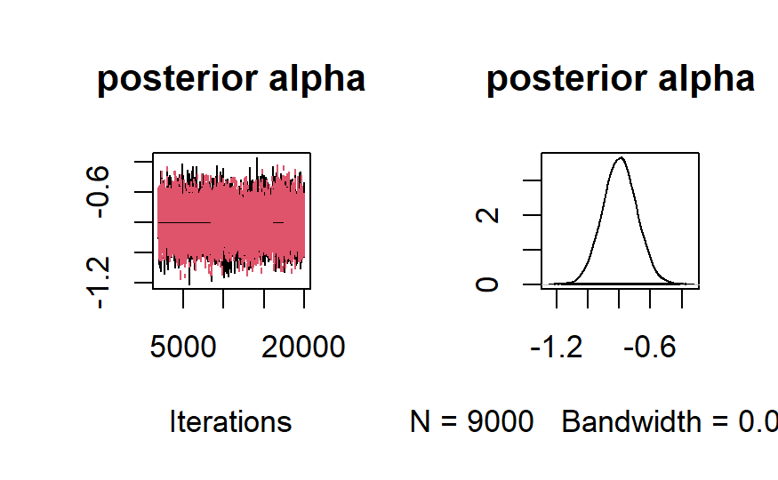

```r
# Trace and density
plot(samples1$samples[,c('alpha')], main="posterior alpha")
```

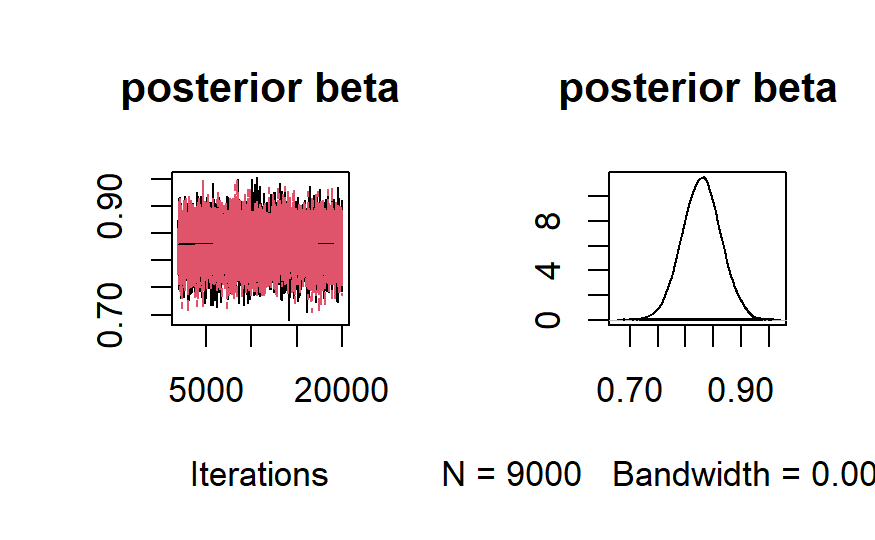

```r
plot(samples1$samples[,c('beta')], main="posterior beta")
```

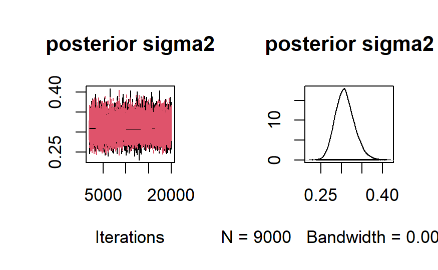

```r
plot(samples1$samples[,c('sigma2')], main="posterior sigma2")
```

```r
# Autocorrelation
# autocorr.plot(samples1$samples[,c('alpha')], main="ACF alpha")
# autocorr.plot(samples$samples[,c('beta')], main="ACF beta")
# autocorr.plot(samples$samples[,c('sigma2')], main="ACF sigma2")
```

```r
# Plotting the data by country
plot(X, Y,
     xlab = "GDP [1k$]", ylab = "CO2 per capita [tons]",
     main = "CO2 per capita vs GDP (log scale)",
     pch = 20,
     cex = 1,
     col = "black",
     xaxt = 'n',  # suppress default x-axis
     yaxt = 'n'  # suppress default x-axis
     )

# Adding custom x-axis labels
new_labels_x <- c(10^1, 10^2, 10^3, 10^4)
axis(1, at = seq_along(new_labels_x), labels = new_labels_x)
```

```r
# Adding custom y-axis labels
new_labels_y <- c(10^-1, 10^0, 10^1, 10^2, 10^3)
axis(2, at = seq_along(new_labels_y) - 2, labels = new_labels_y)



# Recovering alpha and beta
ss = summary(samples1)
# Alpha
alpha_mean = ss["alpha", "mean"]
alpha_q1 = ss["alpha", "2.5%"]
alpha_q2 = ss["alpha", "97.5%"]
# Beta
beta_mean = ss["beta", "mean"]
beta_q1 = ss["beta", "2.5%"]
beta_q2 = ss["beta", "97.5%"]

# Add a gray background
rect(par("usr")[1], par("usr")[3], par("usr")[2], par("usr")[4], col = "gray90", border = NA)
```

```r
panel.first = grid(col = "white", lty = "dotted")
points(X, Y, pch = 20, cex = 1, col = "black")
```

```r
# Lines
abline(a = alpha_mean, b = beta_mean, col = "red", lwd = 3)
abline(a = alpha_q1, b = beta_q1, col = "red", lty=2, lwd = 3)
```

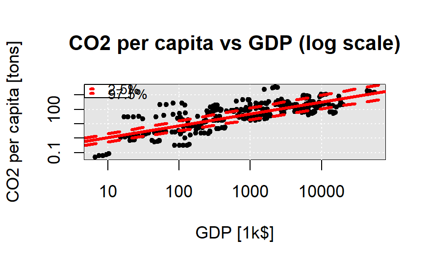

```r
abline(a = alpha_q2, b = beta_q2, col = "red", lty=2, lwd = 3)

# legend
legend("topleft", legend=c("2.5%", "97.5%"), col=c("red", "red"), lty=3, lwd = 3,
       cex=0.8)
```

```r
# ggplot version (ignorare)

# Load necessary library
library(ggplot2)

# Plot
g_bayes = ggplot(data=CO2_subset, aes(x=log(GDP), y=log(co2percap))) +
  geom_point() +
  geom_abline(intercept = alpha_mean, slope = beta_mean, color = "red",
              linewidth = 1) +
  geom_abline(intercept = alpha_q1, slope = beta_q1, color = "red",
              linetype = "dashed", linewidth = 1) +
  geom_abline(intercept = alpha_q2, slope = beta_q2, color = "red",
              linetype = "dashed", linewidth = 1) +
  scale_color_manual(name="Curves", values=c('blue','red')) +
  scale_fill_manual(name="Bands", values='blue')

# g_bayes
```

As we can see from the plot, there is a clear positive linear relationship between GDP and CO2 emissions per capita.

This finding aligns with the analysis performed on **Dataset 1**, explaining why economic **recessions** tend to reduce CO2 emission intensity, whereas periods of **economic growth** correspond with a more rapid increase in emissions.

### Energy Use and CO2 Emissions

We also analyze the direct relationship between CO2 emissions and Energy Use.

Again, we perform the regression on the log scale for better interpretability.

The model is as follow:
$$\begin{split}
& Y_i \sim \mathcal{N}(\alpha+ X_i \beta,\sigma^2) \\
& \alpha \sim \mathcal{N}(0,100) \\
& \beta \sim \mathcal{N}(0, 100)\\
& \frac{1}{\sigma^{2}} \sim \mathcal{G}(0.001,0.001) \\
\end{split}$$

```r
# model
model2 <- textConnection("model{
  # likelihood
    for (i in 1:N) {
        Y[i] ~ dnorm(mu[i], inv.var)
        mu[i] = alpha + X[i] * beta
    }

    # prior
    alpha ~ dnorm(0, .01)
    beta ~ dnorm(0, .01)
    inv.var ~ dgamma(0.001, 0.001)
    sigma2 <- 1/inv.var
}")


# Data
# Y = CO2_subset$co2percap
# X = CO2_subset$EnergyUse
Y = log(CO2_subset$co2percap)         # log
X = log(CO2_subset$EnergyUse)

dataList = list(Y=Y, X=X, N=length(Y))


# Jags
samples2 <- jags(model.file = model2,
                     data=dataList,
                     # inits=inits,
                     parameters.to.save= c("alpha", "beta", "sigma2", "mu"),
                     n.adapt=1000, n.iter=20000, n.chains = 2, n.burnin = 2000,
                     n.thin = 2)
```

[output not shown]

[output cut: 66 more lines]

[output not shown]

```r
# Output
samples2
```

```
JAGS output for model '4', generated by jagsUI.
Estimates based on 2 chains of 20000 iterations,
adaptation = 1000 iterations (sufficient),
burn-in = 2000 iterations and thin rate = 2,
yielding 18000 total samples from the joint posterior.
MCMC ran for 0.023 minutes at time 2024-06-16 15:59:26.341013.
```

|  | mean | sd | 2.5% | 50% | 97.5% | overlap0 | f | Rhat | n.eff |
| --- | --- | --- | --- | --- | --- | --- | --- | --- | --- |
| alpha | -1.494 | 0.059 | -1.610 | -1.494 | -1.379 | FALSE | 1.000 | 1 | 7780 |
| beta | 0.972 | 0.017 | 0.939 | 0.972 | 1.006 | FALSE | 1.000 | 1 | 9691 |
| sigma2 | 0.081 | 0.006 | 0.070 | 0.080 | 0.093 | FALSE | 1.000 | 1 | 18000 |
| mu[1] | 0.870 | 0.021 | 0.828 | 0.870 | 0.912 | FALSE | 1.000 | 1 | 7677 |
| mu[2] | 1.419 | 0.016 | 1.388 | 1.419 | 1.451 | FALSE | 1.000 | 1 | 12076 |
| mu[3] | 2.560 | 0.021 | 2.519 | 2.560 | 2.601 | FALSE | 1.000 | 1 | 18000 |
| mu[4] | 2.260 | 0.018 | 2.225 | 2.260 | 2.295 | FALSE | 1.000 | 1 | 18000 |
| mu[5] | 1.348 | 0.017 | 1.316 | 1.348 | 1.381 | FALSE | 1.000 | 1 | 10832 |
| mu[6] | -0.867 | 0.048 | -0.962 | -0.867 | -0.772 | FALSE | 1.000 | 1 | 7558 |
| mu[7] | 2.559 | 0.021 | 2.517 | 2.559 | 2.600 | FALSE | 1.000 | 1 | 18000 |

[output cut: 353 more lines]

```
Successful convergence based on Rhat values (all < 1.1).
Rhat is the potential scale reduction factor (at convergence, Rhat=1).
For each parameter, n.eff is a crude measure of effective sample size.

overlap0 checks if 0 falls in the parameter's 95% credible interval.
f is the proportion of the posterior with the same sign as the mean;
i.e., our confidence that the parameter is positive or negative.

DIC info: (pD = var(deviance)/2)
pD = 3 and DIC = 116.787
DIC is an estimate of expected predictive error (lower is better).
```

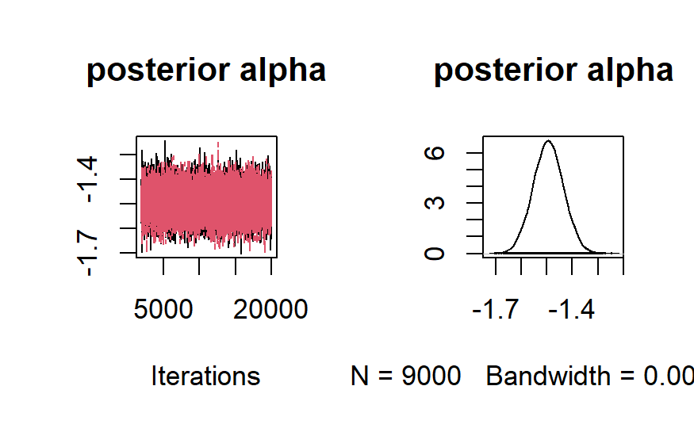

```r
# Trace and density
plot(samples2$samples[,c('alpha')], main="posterior alpha")
```

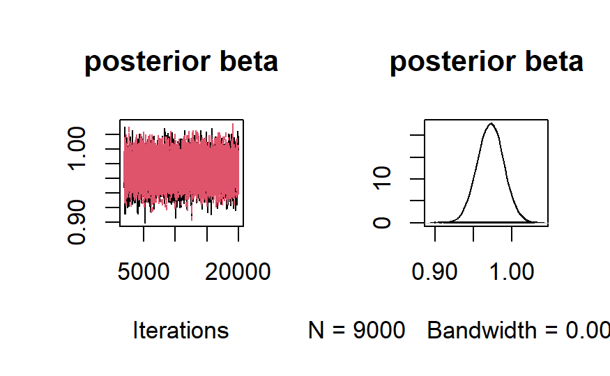

```r
plot(samples2$samples[,c('beta')], main="posterior beta")
```

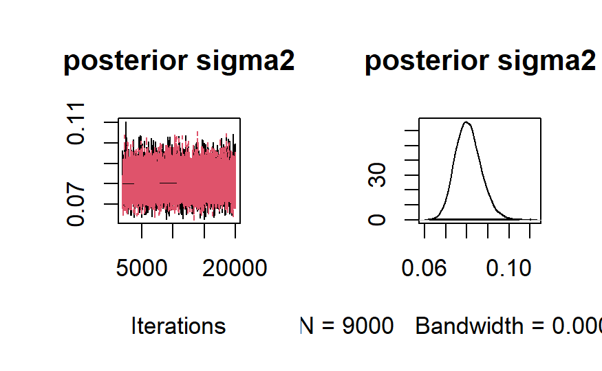

```r
plot(samples2$samples[,c('sigma2')], main="posterior sigma2")
```

```r
# Plotting the data by country
plot(X, Y,
     xlab = "Energy Use [tons oil eq. per cap]", ylab = "CO2 per capita [tons]",
     main = "CO2 per capita vs Energy Use (log scale)",
     pch = 20,
     cex = 1,
     col = "black",
     xaxt = 'n',  # suppress default x-axis
     yaxt = 'n'  # suppress default x-axis
     )

# # Adding custom x-axis labels
new_labels_x <- c(10^1, 10^2, 10^3, 10^4, 10^5)
axis(1, at = seq_along(new_labels_x), labels = new_labels_x)
```

```r
#
# # Adding custom y-axis labels
new_labels_y <- c(10^-1, 10^0, 10^1, 10^2, "1e3")
axis(2, at = seq_along(new_labels_y) - 2, labels = new_labels_y)



# Recovering alpha and beta
ss = summary(samples2)
# Alpha
alpha_mean = ss["alpha", "mean"]
alpha_q1 = ss["alpha", "2.5%"]
alpha_q2 = ss["alpha", "97.5%"]
# Beta
beta_mean = ss["beta", "mean"]
beta_q1 = ss["beta", "2.5%"]
beta_q2 = ss["beta", "97.5%"]

# Add a gray background
rect(par("usr")[1], par("usr")[3], par("usr")[2], par("usr")[4], col = "gray90", border = NA)
```

```r
panel.first = grid(col = "white", lty = "dotted")
points(X, Y, pch = 20, cex = 1, col = "black")
```

```r
# Lines
abline(a = alpha_mean, b = beta_mean, col = "red", lwd = 3)
abline(a = alpha_q1, b = beta_q1, col = "red", lty=2, lwd = 3)
```

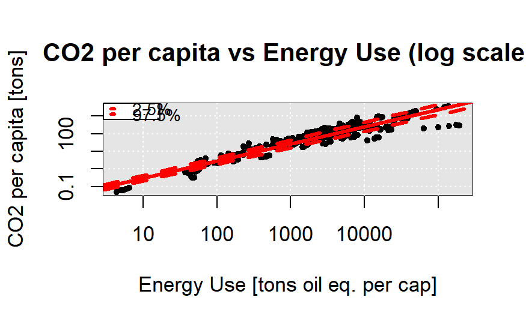

```r
abline(a = alpha_q2, b = beta_q2, col = "red", lty=2, lwd = 3)

# legend
legend("topleft", legend=c("2.5%", "97.5%"), col=c("red", "red"), lty=3, lwd = 3,
       cex=0.8)
```

The analysis reveals a strong linear relationship between Energy Use and CO2 emissions per capita.

However, there are some data points that appear to be outliers. While these outliers are less evident in the log plot, they become more noticeable when plotted on the real scale.

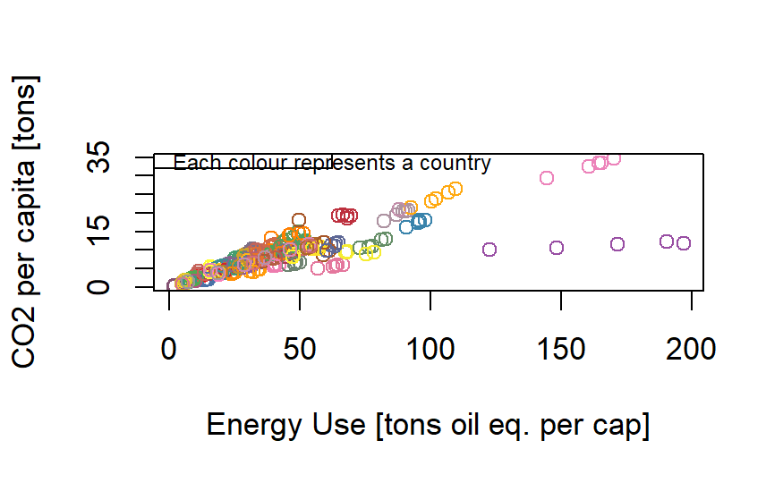

```r
# Plotting the data by country
plot(CO2$EnergyUse, CO2$co2percap,
     xlab = "Energy Use [tons oil eq. per cap]", ylab = "CO2 per capita [tons]",
     # log = "xy",
     col = palette_colors[as.numeric(factor(CO2$country))]
     )

legend("topleft", legend="Each colour represents a country", cex=0.7)
```

```r
# Selecting the outlier country
# Subset the data
selected_countries <- subset(CO2, co2percap < 20 & EnergyUse > 100)

# View the selected countries
countries = unique(selected_countries$country)

selected_countries
```

|  | X | country | y | EnergyUse | GDP | pop | co2percap | Lowcarbon_energy | internet | urb | internet_users_ratio |
| --- | --- | --- | --- | --- | --- | --- | --- | --- | --- | --- | --- |
| 26 | 134 | Iceland | 2005 | 122.4043 | 48.10465 | 0.294976 | 10.0902 | 67.457 | 256632 | 93.037 | 87.00098 |
| 99 | 1341 | Iceland | 2006 | 148.0965 | 49.95685 | 0.299727 | 10.5193 | 69.839 | 268287 | 93.159 | 89.51045 |
| 172 | 1342 | Iceland | 2007 | 171.4963 | 52.82701 | 0.305181 | 11.4558 | 73.328 | 276511 | 93.278 | 90.60558 |
| 245 | 1343 | Iceland | 2008 | 190.1951 | 52.99944 | 0.310855 | 12.2612 | 80.334 | 282904 | 93.395 | 91.00835 |
| 318 | 1344 | Iceland | 2009 | 196.6759 | 48.77095 | 0.316057 | 11.7943 | 81.746 | 293960 | 93.511 | 93.00854 |

```r
countries
```

```
[1] "Iceland"
```

Upon closer inspection, the only outlier is Iceland.

Iceland’s relatively low CO2 emissions can be attributed to its substantial use of low-carbon energy sources, which accounted for up to 80% of its energy production in 2009.

### Low carbon Energy

Low-carbon energy is de fined as the sum of nuclear and renewable sources. Intuitively it is reasonable to expect to find a negative relation with the CO2 emissions.

```r
# Exponential response
# model3 <- textConnection("model{
#   # likelihood
#   for (i in 1:N) {
#       # Y[i] ~ dnorm(mu[i], inv.s)
#       Y[i] ~ dexp(mu[i])
#       log(mu[i]) = alpha + X[i] * beta
#   }
#
#   # prior
#   alpha ~ dnorm(0, .001)
#   beta ~ dnorm(0, .001)
#   inv.s ~ dgamma(0.001, 0.001)
# }")

# Normal model
model3 <- textConnection("model{
  # likelihood
    for (i in 1:N) {
        Y[i] ~ dnorm(mu[i], inv.var)
        # Y[i] ~ dexp(mu[i])
        mu[i] = alpha + X[i] * beta
    }

    # prior
    alpha ~ dnorm(0, .01)
    beta ~ dnorm(0, .01)
    inv.var ~ dgamma(0.001, 0.001)
    sigma2 <- 1/inv.var
}")


# Data
Y = CO2_subset$co2percap
X = CO2_subset$Lowcarbon_energy
# Y = log(CO2_subset$co2percap)         # log
# X = log(CO2_subset$Lowcarbon_energy)

dataList = list(Y=Y, X=X, N=length(Y))


# Jags
samples3 <- jags(model.file = model3,
                     data=dataList,
                     # inits=inits,
                     parameters.to.save= c("alpha", "beta", "mu", "sigma2"),
                     n.adapt=1000, n.iter=20000, n.chains = 2, n.burnin = 2000,
                     n.thin = 2)
```

[output not shown]

[output cut: 66 more lines]

[output not shown]

```r
# Output
samples3
```

```
JAGS output for model '5', generated by jagsUI.
Estimates based on 2 chains of 20000 iterations,
adaptation = 1000 iterations (sufficient),
burn-in = 2000 iterations and thin rate = 2,
yielding 18000 total samples from the joint posterior.
MCMC ran for 0.024 minutes at time 2024-06-16 15:59:40.923708.
```

|  | mean | sd | 2.5% | 50% | 97.5% | overlap0 | f | Rhat | n.eff |
| --- | --- | --- | --- | --- | --- | --- | --- | --- | --- |
| alpha | 8.048 | 0.410 | 7.249 | 8.048 | 8.855 | FALSE | 1.000 | 1 | 18000 |
| beta | -0.029 | 0.018 | -0.065 | -0.029 | 0.008 | TRUE | 0.941 | 1 | 18000 |
| mu[1] | 8.036 | 0.405 | 7.246 | 8.036 | 8.834 | FALSE | 1.000 | 1 | 18000 |
| mu[2] | 7.590 | 0.299 | 7.009 | 7.591 | 8.181 | FALSE | 1.000 | 1 | 18000 |
| mu[3] | 7.933 | 0.363 | 7.219 | 7.933 | 8.650 | FALSE | 1.000 | 1 | 18000 |
| mu[4] | 7.286 | 0.365 | 6.576 | 7.285 | 8.001 | FALSE | 1.000 | 1 | 18000 |
| mu[5] | 7.908 | 0.355 | 7.208 | 7.910 | 8.609 | FALSE | 1.000 | 1 | 18000 |
| mu[6] | 8.017 | 0.397 | 7.242 | 8.018 | 8.798 | FALSE | 1.000 | 1 | 18000 |
| mu[7] | 7.539 | 0.303 | 6.949 | 7.539 | 8.136 | FALSE | 1.000 | 1 | 18000 |
| mu[8] | 6.823 | 0.589 | 5.673 | 6.818 | 7.963 | FALSE | 1.000 | 1 | 18000 |

[output cut: 353 more lines]

```
Successful convergence based on Rhat values (all < 1.1).
Rhat is the potential scale reduction factor (at convergence, Rhat=1).
For each parameter, n.eff is a crude measure of effective sample size.

overlap0 checks if 0 falls in the parameter's 95% credible interval.
f is the proportion of the posterior with the same sign as the mean;
i.e., our confidence that the parameter is positive or negative.

DIC info: (pD = var(deviance)/2)
pD = 3.1 and DIC = 2264.549
DIC is an estimate of expected predictive error (lower is better).
```

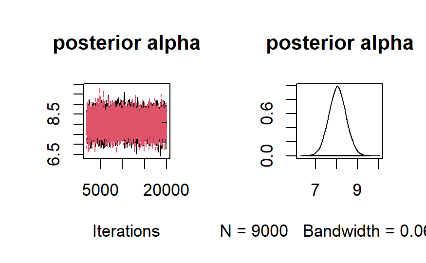

```r
# Trace and density
plot(samples3$samples[,c('alpha')], main="posterior alpha")
```